# NHANES Data Analysis

Chanese A. Forte & Jess A. Millar

# Data

## Load NHANES datasets

Load the various environmental sample datasets, with demographics information included.

```r
bake(file="rds/deet.rds",{
  # downloading all of the data with demographics information attached.
  nhanes_load_data("OPD_D", "2005-2006" , demographics=TRUE) %>%
    dplyr::select(-file_name, -begin_year, -end_year) -> dat1
  nhanes_load_data("OPD_E", "2007-2008" , demographics=TRUE) %>%
    dplyr::select(-file_name, -begin_year, -end_year) -> dat2
  nhanes_load_data("OPD_G", "2011-2012" , demographics=TRUE) %>%
    dplyr::select(-file_name, -begin_year, -end_year) -> dat3

  # joining the data by lab results
  full_join(dat1,dat2, by=NULL) %>%
    full_join(dat3, by=NULL) %>%
    arrange_all(desc) %>% distinct() ->opd

  # Only 1 row per SEQN
  stopifnot(
    opd %>%
      group_by(SEQN) %>%
      summarise(total=n()) %>%
      filter(total>1) %>% nrow()==0
  )

  #################################################################

  nhanes_load_data("CARB_D", "2005-2006" , demographics=TRUE) %>%
    dplyr::select(-file_name, -begin_year, -end_year) -> dat4
  nhanes_load_data("CARB_E", "2007-2008" , demographics=TRUE) %>%
    dplyr::select(-file_name, -begin_year, -end_year) -> dat5

  full_join(dat4,dat5,by=NULL) %>%
    full_join(opd, by=NULL) %>%
    arrange_all(desc) %>% distinct() %>%
    group_by(SEQN) %>%
    tidyr::fill(names(.), .direction="downup") %>%
    ungroup() %>% distinct() %>%
    group_by(SEQN) %>%
    slice(1) %>%
    ungroup() ->carb

  # Only 1 row per SEQN
  stopifnot(
    carb %>%
      group_by(SEQN) %>%
      summarise(total=n()) %>%
      filter(total>1) %>% nrow()==0
  )

  #################################################################

  nhanes_load_data("LAB26PP", "1999-2000" , demographics=TRUE) %>%
    dplyr::select(-file_name, -begin_year, -end_year) -> dat6
  nhanes_load_data("L26PP_B", "2001-2002" , demographics=TRUE) %>%
    dplyr::select(-file_name, -begin_year, -end_year) -> dat7

  # by removing "file_name", we avoided 5,450 duplicates
  full_join(dat6,dat7,by=NULL) %>%
    full_join(carb, by=NULL) %>%
    arrange_all(desc) %>% distinct() %>%
    group_by(SEQN) %>%
    tidyr::fill(names(.), .direction="downup") %>%
    ungroup() %>% distinct() %>%
    group_by(SEQN) %>%
    slice(1) %>%
    ungroup() -> pp

  # Only 1 row per SEQN
  stopifnot(
    pp %>%
      group_by(SEQN) %>%
      summarise(total=n()) %>%
      filter(total>1) %>% nrow()==0
  )

  #################################################################

  nhanes_load_data("L26UPP_C", "2003-2004" , demographics=TRUE) %>%
    dplyr::select(-file_name, -begin_year, -end_year) -> dat8
  nhanes_load_data("UPP_D", "2005-2006" , demographics=TRUE) %>%
    dplyr::select(-file_name, -begin_year, -end_year) -> dat9
  nhanes_load_data("UPP_E", "2007-2008" , demographics=TRUE) %>%
    dplyr::select(-file_name, -begin_year, -end_year) -> dat10

  # by removing "file_name", we avoided 10,900 duplicates
  full_join(dat8,dat9,by=NULL) %>%
    full_join(dat10, by=NULL) %>%
    full_join(pp, by=NULL) %>%
    arrange_all(desc) %>% distinct() %>%
    group_by(SEQN) %>%
    tidyr::fill(names(.), .direction="downup") %>%
    ungroup() %>% distinct() %>%
    group_by(SEQN) %>%
    slice(1) %>%
    ungroup() -> upp

  # Only 1 row per SEQN
  stopifnot(
    upp %>%
      group_by(SEQN) %>%
      summarise(total=n()) %>%
      filter(total>1) %>% nrow()==0
  )

  #################################################################

  nhanes_load_data("L24PP_C", "2003-2004" , demographics=TRUE) %>%
    dplyr::select(-file_name, -begin_year, -end_year) -> dat11
  nhanes_load_data("PP_D", "2005-2006" , demographics=TRUE) %>%
    dplyr::select(-file_name, -begin_year, -end_year) -> dat12
  nhanes_load_data("PP_E", "2007-2008" , demographics=TRUE) %>%
    dplyr::select(-file_name, -begin_year, -end_year) -> dat13
  nhanes_load_data("PP_F", "2009-2010" , demographics=TRUE) %>%
    dplyr::select(-file_name, -begin_year, -end_year) -> dat14
  nhanes_load_data("PP_G", "2011-2012" , demographics=TRUE) %>% #incomplete dataset
    dplyr::select(-file_name, -begin_year, -end_year) -> dat15

  full_join(dat11,dat12,by=NULL) %>%
    full_join(dat13, by=NULL) %>%
    full_join(dat14, by=NULL) %>%
    full_join(dat15, by=NULL) %>%
    full_join(upp, by=NULL) %>%
    arrange_all(desc) %>% distinct() %>%
    group_by(SEQN) %>%
    tidyr::fill(names(.), .direction="downup") %>%
    ungroup() %>% distinct() %>%
    group_by(SEQN) %>%
    slice(1) %>%
    ungroup() -> L24

  # Only 1 row per SEQN
  stopifnot(
    L24 %>%
      group_by(SEQN) %>%
      summarise(total=n()) %>%
      filter(total>1) %>% nrow()==0
  )

  #################################################################

  nhanes_load_data("LAB28POC", "1999-2000" , demographics=TRUE) %>%
    dplyr::select(-file_name, -begin_year, -end_year) -> dat16
  nhanes_load_data("L28POC_B", "2001-2002" , demographics=TRUE) %>%
    dplyr::select(-file_name, -begin_year, -end_year) -> dat17
  nhanes_load_data("L28OCP_C", "2003-2004" , demographics=TRUE) %>% #incomplete dataset
    dplyr::select(-file_name, -begin_year, -end_year) -> dat18

  full_join(dat16,dat17,by=NULL) %>%
    full_join(dat18, by=NULL) %>%
    full_join(L24, by=NULL) %>%
    arrange_all(desc) %>% distinct() %>%
    group_by(SEQN) %>%
    tidyr::fill(names(.), .direction="downup") %>%
    ungroup() %>% distinct() %>%
    group_by(SEQN) %>%
    slice(1) %>%
    ungroup() -> L28

  # Only 1 row per SEQN
  stopifnot(
    L28 %>%
      group_by(SEQN) %>%
      summarise(total=n()) %>%
      filter(total>1) %>% nrow()==0
  )

  # L28 %>%
  #     group_by(SEQN) %>%
  #     summarise(total=n()) %>%
  #     filter(total>1) %>% pull(SEQN) -> duplicate_SEQN
  #
  # library(arsenal)
  # L28 %>% filter(SEQN==7) ->a
  # comparedf(a[1,],a[2,])

  #################################################################

  nhanes_load_data("UPHOPM_F", "2009-2010" , demographics=TRUE) %>%
    dplyr::select(-file_name, -begin_year, -end_year) -> dat19
  nhanes_load_data("UPHOPM_G", "2011-2012" , demographics=TRUE) %>%
    dplyr::select(-file_name, -begin_year, -end_year) -> dat20
  nhanes_load_data("UPHOPM_H", "2013-2014" , demographics=TRUE) %>%
    dplyr::select(-file_name, -begin_year, -end_year) -> dat21

  full_join(dat19,dat20,by=NULL) %>%
    full_join(dat21, by=NULL) %>%
    full_join(L28, by=NULL) %>%
    arrange_all(desc) %>% distinct() %>%
    group_by(SEQN) %>%
    tidyr::fill(names(.), .direction="downup") %>%
    ungroup() %>% distinct() %>%
    group_by(SEQN) %>%
    slice(1) %>%
    ungroup() -> uphop

  # Only 1 row per SEQN
  stopifnot(
    uphop %>%
      group_by(SEQN) %>%
      summarise(total=n()) %>%
      filter(total>1) %>% nrow()==0
  )

  #################################################################

  nhanes_load_data("DEET_E", "2007-2008" , demographics=TRUE) %>%
    dplyr::select(-file_name, -begin_year, -end_year) -> dat22
  nhanes_load_data("DEET_F", "2009-2010" , demographics=TRUE) %>%
    dplyr::select(-file_name, -begin_year, -end_year) -> dat23
  nhanes_load_data("DEET_G", "2011-2012" , demographics=TRUE) %>%
    dplyr::select(-file_name, -begin_year, -end_year) -> dat24
  nhanes_load_data("DEET_H", "2013-2014" , demographics=TRUE) %>%
    dplyr::select(-file_name, -begin_year, -end_year) -> dat25

  nhanes_load_data("UAM_E", "2007-2008" , demographics=TRUE) %>%
    dplyr::select(-file_name, -begin_year, -end_year) -> uam

  full_join(uphop,dat22,by=NULL) %>%
    full_join(dat23, by=NULL) %>%
    full_join(dat24, by=NULL) %>%
    full_join(dat25, by=NULL) %>%
    full_join(uam, by=NULL) %>%
    arrange(SEQN) %>% distinct() %>%
    group_by(SEQN) %>%
    tidyr::fill(names(.), .direction="downup") %>%
    ungroup() %>% distinct() %>%
    group_by(SEQN) %>%
    slice(1) %>%
    ungroup() -> deet
}) -> deet

# Only 1 row per SEQN
stopifnot(
  deet %>%
    group_by(SEQN) %>%
    summarise(total=n()) %>%
    filter(total>1) %>% nrow()==0
)

# SEQNs for chemical data
deet %>% arrange(SEQN) %>% pull(SEQN) %>% unique() -> chem_assoc_SEQN
```

Load other demographic data.

```r
bake(file="rds/occ.rds",{
# Inputting occupational data
# Vars: SEQN, OCD230, OCD231, OCD240, OCD241, OCD390, OCD391, OCD392
  remove_all_labels(nhanes('OCQ')) %>%
    mutate(cycle = "1999-2000", SDDSRVYR = 1) -> occ_2000
  remove_all_labels(nhanes('OCQ_B')) %>%
    mutate(cycle = "2001-2002", SDDSRVYR = 2) -> occ_2002
  remove_all_labels(nhanes('OCQ_C')) %>%
    mutate(cycle = "2003-2004", SDDSRVYR = 3) -> occ_2004
  remove_all_labels(nhanes('OCQ_D')) %>%
    mutate(cycle = "2005-2006", SDDSRVYR = 4) -> occ_2006
  remove_all_labels(nhanes('OCQ_E')) %>%
    mutate(cycle = "2007-2008", SDDSRVYR = 5) -> occ_2008
  remove_all_labels(nhanes('OCQ_F')) %>%
    mutate(cycle = "2009-2010", SDDSRVYR = 6) -> occ_2010
  remove_all_labels(nhanes('OCQ_G')) %>%
    mutate(cycle = "2011-2012", SDDSRVYR = 7) -> occ_2012
  remove_all_labels(nhanes('OCQ_H')) %>%
    mutate(cycle = "2013-2014", SDDSRVYR = 8) -> occ_2014
  # occ_2016 <- nhanes('OCQ_I')

  full_join(occ_2000,occ_2002,by=NULL) %>%
    full_join(occ_2004, by=NULL) %>%
    full_join(occ_2006, by=NULL) %>%
    full_join(occ_2008, by=NULL) %>%
    full_join(occ_2010, by=NULL) %>%
    full_join(occ_2012, by=NULL) %>%
    full_join(occ_2014, by=NULL) %>%
    arrange_all(desc) %>% distinct() %>%
    dplyr::select(SEQN, cycle, SDDSRVYR, OCD230, OCD231, OCD240, OCD241, OCD390, OCD391, OCD392) %>%
    filter(!is.na(OCD230) | !is.na(OCD231) | !is.na(OCD240) | !is.na(OCD241) |
           !is.na(OCD390) | !is.na(OCD391) | !is.na(OCD392)) %>%
    mutate(farmwork = case_when(
      OCD230 %in% c(1,2) ~ 1,
      OCD231 ==   1      ~ 1,
      OCD390 %in% c(1,2) ~ 1,
      OCD391 ==   1      ~ 1,
      OCD392 ==   18     ~ 1,
      TRUE               ~ 0
    ),
    farmwork_sp = case_when(
      OCD230 %in% c(1,2) ~ 1,
      OCD231 ==   1      ~ 1,
      OCD240 %in% c(1,2) ~ 1,
      OCD241 ==   18     ~ 1,
      OCD390 %in% c(1,2) ~ 1,
      OCD391 ==   1      ~ 1,
      OCD392 ==   18     ~ 1,
      TRUE               ~ 0
    )) %>%
    filter(SEQN %in% chem_assoc_SEQN) -> occ
  }) -> occ

# Only 1 row per SEQN
stopifnot(
  occ %>%
    group_by(SEQN) %>%
    summarise(total=n()) %>%
    filter(total>1) %>% nrow()==0
)

# CBC
# cbc_2000 <- nhanes('LAB25')
# cbc_2002 <- nhanes('L25_B')
# cbc_2004 <- nhanes('L25_C')
# cbc_2006 <- nhanes('CBC_D')
# cbc_2008 <- nhanes('CBC_E')
# cbc_2010 <- nhanes('CBC_F')
# cbc_2012 <- nhanes('CBC_G')  #double check this dataset
# cbc_2014 <- nhanes('CBC_H')
# cbc_2016 <- nhanes('CBC_I')

bake(file="rds/bmi.rds",{
  # BMI dataset
  # Vars: SEQN, BMXBMI
  remove_all_labels(nhanes('BMX')) %>%
    mutate(cycle = "1999-2000", SDDSRVYR = 1) -> bmi2000
  remove_all_labels(nhanes('BMX_B')) %>%
    mutate(cycle = "2001-2002", SDDSRVYR = 2) -> bmi2002
  remove_all_labels(nhanes('BMX_C')) %>%
    mutate(cycle = "2003-2004", SDDSRVYR = 3) -> bmi2004
  remove_all_labels(nhanes('BMX_D')) %>%
    mutate(cycle = "2005-2006", SDDSRVYR = 4) -> bmi2006
  remove_all_labels(nhanes('BMX_E')) %>%
    mutate(cycle = "2007-2008", SDDSRVYR = 5) -> bmi2008
  remove_all_labels(nhanes('BMX_F')) %>%
    mutate(cycle = "2009-2010", SDDSRVYR = 6) -> bmi2010
  remove_all_labels(nhanes('BMX_G')) %>%
    mutate(cycle = "2011-2012", SDDSRVYR = 7) -> bmi2012
  remove_all_labels(nhanes('BMX_H')) %>%
    mutate(cycle = "2013-2014", SDDSRVYR = 8) -> bmi2014
  # bmi2016 <- nhanes('BMX_I')

  full_join(bmi2000,bmi2002,by=NULL) %>%
    full_join(bmi2004, by=NULL) %>%
    full_join(bmi2006, by=NULL) %>%
    full_join(bmi2008, by=NULL) %>%
    full_join(bmi2010, by=NULL) %>%
    full_join(bmi2012, by=NULL) %>%
    full_join(bmi2014, by=NULL) %>%
    arrange_all(desc) %>% distinct() %>%
    dplyr::select(SEQN, cycle, BMXBMI) %>%
    filter(!is.na(BMXBMI)) %>%
    filter(SEQN %in% chem_assoc_SEQN) -> bmi
}) -> bmi

stopifnot(
  bmi %>%
    group_by(SEQN) %>%
    summarise(total=n()) %>%
    filter(total>1) %>% nrow()==0
)
```

Combine to final large dataset.

```r
bake(file="rds/nhanes_all_dat.rds",{
  #merging datsets with the same variables
  full_join(deet, occ, by=NULL) %>%
    full_join(bmi, by=NULL) %>%
    arrange_all(desc) %>% distinct() %>%
    group_by(SEQN) %>%
    tidyr::fill(names(.), .direction="downup") %>%
    ungroup() %>% distinct() %>%
    group_by(SEQN) %>%
    slice(1) %>%
    ungroup() %>%
    mutate(edu = DMDEDUC2,
           edu = case_when(
      DMDEDUC3 %in% c(1:8,55,66) ~ 1,
      DMDEDUC3 %in% c(9:12)      ~ 2,
      DMDEDUC3 %in% c(13:14)     ~ 3,
      DMDEDUC3 ==   15           ~ 4,
      DMDEDUC3 %in% c(77,99)     ~ NA_real_,
      DMDEDUC2 %in% c(7,9)       ~ NA_real_,
      TRUE                       ~ as.numeric(DMDEDUC2)
     )) %>%
    mutate(
           #URXCPF   = URXCPM,
           #URXCPO   = URXCPM,
           URDCPFLC = URDCPMLC,
           URDCPOLC = URDCPMLC,
           LBXBHC   = coalesce(LBXBHC, LBDBHC),
           LBXBHCLA = coalesce(LBXBHCLA, LBDBHCLA)) %>%
    rename(LBX199   = LBD199,
           URXSIM   = URXSISM) %>%
    dplyr::select(-LBDBHC, -LBDBHCLA) -> all_dat
}) -> all_dat

# Only 1 row per SEQN
stopifnot(
  all_dat %>%
    group_by(SEQN) %>%
    summarise(total=n()) %>%
    filter(total>1) %>% nrow()==0
)
```

## Create weighting variables

Create weighting variables to be used for the chemicals.

```r
# raw, lipid adjusted, positive= LA, LC
all_dat %>%
  dplyr::select(!starts_with(c("WTI","WTMR","SIA",
                               "MIA","FIA","AIA","DMQ"))) %>%
  mutate(
    WTMEC16YR = case_when(
      SDDSRVYR %in% c(1,2)   ~ (2/8)*WTMEC4YR, # for 1999-2002
      SDDSRVYR %in% c(3:8)   ~ (1/8)*WTMEC2YR, # for 2003-2014
      TRUE                   ~ NA_real_),
    WT_LBXBHC = ifelse(is.finite(LBXBHC), case_when(
      SDDSRVYR %in% c(1,2)   ~ (2/3)*WTSPO4YR, # for 1999-2002
      SDDSRVYR %in% c(3)     ~ (1/3)*WTSB2YR,  # for 2003-2004
      TRUE                   ~ NA_real_
    ), NA_real_),
    WT_LBXDIE = ifelse(is.finite(LBXDIE), case_when(
      SDDSRVYR %in% c(2)     ~ (1/2)*WTSPO2YR, # for 2001-2002
      SDDSRVYR %in% c(3)     ~ (1/2)*WTSB2YR,  # for 2003-2004
      TRUE                   ~ NA_real_
    ), NA_real_),
    WT_LBXHPE = ifelse(is.finite(LBXHPE), case_when(
      SDDSRVYR %in% c(1,2)   ~ (2/3)*WTSPO4YR, # for 1999-2002
      SDDSRVYR %in% c(3)     ~ (1/3)*WTSB2YR,  # for 2003-2004
      TRUE                   ~ NA_real_
    ), NA_real_),
    WT_LBXPDE = ifelse(is.finite(LBXPDE), case_when(
      SDDSRVYR %in% c(1,2)   ~ (2/3)*WTSPO4YR, # for 1999-2002
      SDDSRVYR %in% c(3)     ~ (1/3)*WTSB2YR,  # for 2003-2004
      TRUE                   ~ NA_real_
    ), NA_real_),
    WT_LBXPDT = ifelse(is.finite(LBXPDT), case_when(
      SDDSRVYR %in% c(1,2)   ~ (2/3)*WTSPO4YR, # for 1999-2002
      SDDSRVYR %in% c(3)     ~ (1/3)*WTSB2YR,  # for 2003-2004
      TRUE                   ~ NA_real_
    ), NA_real_),
    WT_URX24D = ifelse(is.finite(URX24D), case_when(
      SDDSRVYR %in% c(1,2)   ~ (2/6)*WTSPP4YR, # for 1999-2002
      SDDSRVYR %in% c(3,6:8) ~ (1/6)*WTSC2YR,  # for 2003-2004, 2009-2014
      TRUE                   ~ NA_real_
    ), NA_real_),
    WT_URXDEA = ifelse(is.finite(URXDEA), case_when(
      SDDSRVYR %in% c(5:8)   ~ (1/4)*WTSC2YR,  # for 2007-2014
      TRUE                   ~ NA_real_
    ), NA_real_),
    WT_URXOPM = ifelse(is.finite(URXOPM), case_when(
      SDDSRVYR %in% c(1,2)   ~ (2/5)*WTSPP4YR, # for 1999-2002
      SDDSRVYR %in% c(6:8)   ~ (1/5)*WTSC2YR,  # for 2009-2014
      TRUE                   ~ NA_real_
    ), NA_real_),
    WT_URXPAR = ifelse(is.finite(URXPAR), case_when(
      SDDSRVYR %in% c(1,2)   ~ (2/5)*WTSPP4YR, # for 1999-2002
      SDDSRVYR %in% c(6:8)   ~ (1/5)*WTSC2YR,  # for 2009-2014
      TRUE                   ~ NA_real_
    ), NA_real_),
    WT_URXCPM = ifelse(is.finite(URXCPM), case_when(
      SDDSRVYR %in% c(1,2)   ~ (2/4)*WTSPP4YR, # for 1999-2002
      SDDSRVYR %in% c(6,8)   ~ (1/4)*WTSC2YR,  # for 2009-2010, 2013-2014
      TRUE                   ~ NA_real_
    ), NA_real_),
    # WT_URXCPF = ifelse(is.finite(URXCPF), case_when(
    #   SDDSRVYR %in% c(1,2)   ~ (2/4)*WTSPP4YR, # for 1999-2002
    #   SDDSRVYR %in% c(6,8)   ~ (1/4)*WTSC2YR,  # for 2009-2010, 2013-2014
    #   TRUE                   ~ NA_real_
    # ), NA_real_),
    # WT_URXCPO = ifelse(is.finite(URXCPO), case_when(
    #   SDDSRVYR %in% c(1,2)   ~ (2/4)*WTSPP4YR, # for 1999-2002
    #   SDDSRVYR %in% c(6,8)   ~ (1/4)*WTSC2YR,  # for 2009-2010, 2013-2014
    #   TRUE                   ~ NA_real_
    # ), NA_real_),
    WT_MEC_URX14D = ifelse(is.finite(URX14D), case_when(
      SDDSRVYR %in% c(3:7)   ~ (1/5)*WTMEC2YR,  # for 2004-2012 (all URX14D)
      TRUE                   ~ NA_real_
    ), NA_real_),
    WT_A_URX14D = ifelse(is.finite(URX14D), case_when(
      SDDSRVYR %in% c(7)     ~ WTSA2YR,         # for 2011-2012 (subsample A)
      TRUE                   ~ NA_real_
    ), NA_real_),
    WT_B_URX14D = ifelse(is.finite(URX14D), case_when(
      SDDSRVYR %in% c(4:6)   ~ WTSB2YR,         # for 2005-2010 (subsample B)
      TRUE                   ~ NA_real_
    ), NA_real_),
    WT_C_URX14D = ifelse(is.finite(URX14D), case_when(
      SDDSRVYR %in% c(3)     ~ WTSC2YR,         # for 2003-2004 (subsample C)
      TRUE                   ~ NA_real_
    ), NA_real_),
    WT_MEC_URXDCB = ifelse(is.finite(URXDCB), case_when(
      SDDSRVYR %in% c(3:7)   ~ (1/5)*WTMEC2YR,  # for 2004-2012 (all URXDCB)
      TRUE                   ~ NA_real_
    ), NA_real_),
    WT_A_URXDCB = ifelse(is.finite(URXDCB), case_when(
      SDDSRVYR %in% c(7)     ~ WTSA2YR,         # for 2011-2012 (subsample A)
      TRUE                   ~ NA_real_
    ), NA_real_),
    WT_B_URXDCB = ifelse(is.finite(URXDCB), case_when(
      SDDSRVYR %in% c(4:6)   ~ WTSB2YR,         # for 2005-2010 (subsample B)
      TRUE                   ~ NA_real_
    ), NA_real_),
    WT_C_URXDCB = ifelse(is.finite(URXDCB), case_when(
      SDDSRVYR %in% c(3)     ~ WTSC2YR,         # for 2003-2004 (subsample C)
      TRUE                   ~ NA_real_
    ), NA_real_)) -> all_dat2

data.frame(matrix(c("LBXBHC", "LBXDIE", "LBXHPE", "LBXPDE", "LBXPDT",
                    "URX24D", "URXDEA", "URXOPM", "URXPAR", "URXCPM",
                    #"URXCPF", "URXCPO",
                    "URX14D", "URX14D", "URX14D",
                    "URX14D", "URXDCB", "URXDCB", "URXDCB", "URXDCB",
                    "WT_LBXBHC", "WT_LBXDIE", "WT_LBXHPE", "WT_LBXPDE", "WT_LBXPDT",
                    "WT_URX24D", "WT_URXDEA", "WT_URXOPM", "WT_URXPAR", "WT_URXCPM",
                    #"WT_URXCPF", "WT_URXCPO",
                    "WT_MEC_URX14D", "WT_A_URX14D", "WT_B_URX14D", "WT_C_URX14D",
                    "WT_MEC_URXDCB", "WT_A_URXDCB", "WT_B_URXDCB", "WT_C_URXDCB"), ncol=2)) %>%
  rename(chemical = X1, weight= X2) -> chem_weight_names
```

## Format data

Extend chemical data into a long format.

Several chemicals do not have LC values:

```r
bake(file="rds/chem_long.rds",{
  # LBs
  all_dat2 %>%
    dplyr::select(SEQN,starts_with("LB")) %>%
    dplyr::select(SEQN,ends_with("LC")) %>%
    gather(key=chemical,value=LC, -SEQN) %>%
    filter(!is.na(LC)) %>%
    mutate(chemical = stringr::str_replace(chemical, "^LBD", "LBX"),
           chemical = stringr::str_replace(chemical, "LC$", "")) -> dat_lblc

  all_dat2 %>%
    dplyr::select(SEQN,starts_with("LB")) %>%
    dplyr::select(SEQN,ends_with("LA")) %>%
    gather(key=chemical,value=LA, -SEQN) %>%
    filter(!is.na(LA)) %>%
    mutate(chemical = stringr::str_replace(chemical, "LA$", "")) -> dat_lbla

  all_dat2 %>%
    dplyr::select(SEQN,starts_with("LB")) %>%
    dplyr::select(!ends_with(c("LA","LC"))) %>%
    gather(key=chemical,value=measurement, -SEQN) %>%
    filter(!is.na(measurement)) %>%
    full_join(dat_lbla) %>%
    full_join(dat_lblc) -> dat_lb

  # URs
  all_dat2 %>%
    dplyr::select(SEQN,starts_with("UR")) %>%
    dplyr::select(-URXUCR) %>%
    dplyr::select(SEQN,ends_with("LC")) %>%
    gather(key=chemical,value=LC, -SEQN) %>%
    filter(!is.na(LC)) %>%
    mutate(chemical = stringr::str_replace(chemical, "^URD", "URX"),
           chemical = stringr::str_replace(chemical, "LC$", "")) -> dat_urlc

  all_dat2 %>%
    dplyr::select(SEQN,starts_with("UR")) %>%
    dplyr::select(!ends_with("LC")) %>%
    dplyr::select(-URXUCR) %>%
    gather(key=chemical,value=measurement, -SEQN) %>%
    filter(!is.na(measurement)) %>%
    mutate(LA = NA_real_) %>%
    full_join(dat_urlc) -> dat_ur

  # All chemicals
  rbind(dat_lb, dat_ur) -> chem_long
}) -> chem_long

# Do not have LC values
chem_long %>% filter(is.na(LC)) %>% pull(chemical) %>% unique()
```

```
## [1] "URXOP1" "URXOP2" "URXOP3" "URXOP4" "URXOP5" "URXOP6"
```

Demographic data.

```r
# Everything else
all_dat2 %>%
  dplyr::select(URXUCR) -> URXUCR

all_dat2 %>%
  dplyr::select(!starts_with("UR")) %>%
  dplyr::select(!starts_with("LB")) %>%
  dplyr::select(SEQN, SDDSRVYR, SDMVPSU, SDMVSTRA,
                farmwork, farmwork_sp, DMDCITZN, edu,
                BMXBMI, RIDAGEYR, INDFMPIR, RIAGENDR,
                RIDRETH1, DMDBORN, WTMEC16YR, starts_with("WT_")) %>%
  cbind(URXUCR) %>%
  mutate(DMDCITZN = ifelse(DMDCITZN %in% c(7,9), NA_real_, DMDCITZN),
         DMDCITZN = ifelse(DMDCITZN ==1, 0, DMDCITZN), #citizen=0
         DMDCITZN = ifelse(DMDCITZN ==2, 1, DMDCITZN), #non-citizen=1
         DMDCITZN = as.factor(DMDCITZN),
         farmwork = as.factor(farmwork)) -> demo_dat
```

## Load Toxcats and molecular weights datasets

Load toxcast data.

```r
read_delim("data/pestsheet_convert.csv", delim=",",
           col_names=TRUE,
           col_types = "cccnciciinncnnnncncccc")->mw

readRDS("data/Pesticide_Toxcast_5-3-21.rds") %>%
  dplyr::select(aenm, casn, chnm, hitc, modl_acc, IntendedTargetFamily,
                IntendedTargetFamilySub, GeneName, GeneSymbol) %>%
  group_by(casn, IntendedTargetFamily) %>%
  mutate(target_min_log = min(modl_acc, na.rm = TRUE),
         target_max_log = max(modl_acc, na.rm = TRUE),
         target_min_log = ifelse(is.finite(target_min_log), target_min_log, NA_real_),
         target_max_log = ifelse(is.finite(target_max_log), target_max_log, NA_real_)) %>%
  ungroup() %>%
  group_by(casn) %>%
  mutate(chem_min_log = min(modl_acc, na.rm = TRUE),
         chem_max_log = max(modl_acc, na.rm = TRUE),
         chem_min_log = ifelse(is.finite(chem_min_log), chem_min_log, NA_real_),
         chem_max_log = ifelse(is.finite(chem_max_log), chem_max_log, NA_real_)) %>%
  ungroup() %>%
  full_join(mw %>% dplyr::select(chemical, casn, mw,
                            conversion, density=Density)) -> toxcast
```

## Calculate molarity

Calculate molarity for the chemicals.

For blood measurements (LBX), lipid adjusted measurements (LBXLA) have units of $\frac{\mathrm{ng}}{\mathrm{g}}$. We are given molecular weights ($mw$) as $\frac{\mathrm{g}}{\mathrm{mol}}$ and a [serum density of 1.024](https://pubs.acs.org/doi/10.1021/ac50045a052) $\frac{\mathrm{g}}{\mathrm{mL}}$. And so our conversion will look like:

$$\frac{\mathrm{LBXLA}
\cancel{\mathrm{ng}}}{\cancel{\mathrm{g}}} \cdot \frac{1
\cancel{\mathrm{g}}}{10^9 \cancel{\mathrm{ng}}} \frac{1
\cancel{\mathrm{mol}}}{mw \cancel{\mathrm{g}}} \cdot \frac{1.024
\cancel{\mathrm{g}}}{1 \cancel{\mathrm{mL}}} \cdot \frac{10^3
\cancel{\mathrm{mL}}}{1 \mathrm{L}} \cdot \frac{10^6 \mathrm{\mu mol}}{1
\cancel{\mathrm{mol}}} = \frac{\mathrm{LBXLA} \cdot 1.024}{mw}
\frac{\mathrm{\mu mol}}{\mathrm{L}}$$

Most urinary measurements (URX) have units of $\frac{\mathrm{\mu g}}{\mathrm{L}}$. We are given molecular weights ($mw$) as $\frac{\mathrm{g}}{\mathrm{mol}}$. And so our conversion will look like:

$$\frac{\mathrm{URX} \cancel{\mathrm{\mu
g}}}{\cancel{\mathrm{L}}} \cdot \frac{1 \cancel{\mathrm{g}}}{10^6
\cancel{\mathrm{\mu g}}} \frac{1 \cancel{\mathrm{mol}}}{mw
\cancel{\mathrm{g}}} \cdot \frac{10^6 \mathrm{\mu mol}}{1
\cancel{\mathrm{mol}}} = \frac{\mathrm{URX}}{mw} \frac{\mathrm{\mu
mol}}{\mathrm{L}}$$
Creatinine (URXUCR) has units of $\frac{\mathrm{mg}}{\mathrm{dL}}$. We are given a molecular weight of $113.12 \frac{\mathrm{g}}{\mathrm{mol}}$. And so our conversion will look like:

$$\frac{\mathrm{URXUCR}
\cancel{\mathrm{mg}}}{\cancel{\mathrm{dL}}} \cdot \frac{10
\cancel{\mathrm{dL}}}{1 \mathrm{L}} \cdot \frac{1
\cancel{\mathrm{g}}}{10^3 \cancel{\mathrm{mg}}} \frac{1
\cancel{\mathrm{mol}}}{113.12 \cancel{\mathrm{g}}} \cdot \frac{10^6
\mathrm{\mu mol}}{1 \cancel{\mathrm{mol}}} = \frac{\mathrm{URXUCR} \cdot
10^4}{113.12} \frac{\mathrm{\mu mol}}{\mathrm{L}}$$

```r
chem_long %>%
  left_join(toxcast %>%
              dplyr::select(chemical, casn, chem_min_log, mw,
                            conversion, density) %>%
              arrange(chemical, chem_min_log) %>%
              distinct()) %>%
  mutate(molarity =
           #ifelse(is.finite(LA), LA/mw, measurement/mw)
           case_when(
             grepl('^UR', chemical) ~ (measurement/mw), # umol/L
             grepl('^LB', chemical) ~ (LA/mw)*1.024, # umol/L
             TRUE ~ NA_real_
           )
         ) %>%
  mutate(indiv_chem_bioactiv = ifelse(log(molarity) >= chem_min_log, 1, 0)) %>%
  group_by(SEQN) %>%
  mutate(bioactiv_any = max(indiv_chem_bioactiv, na.rm = TRUE),
         bioactiv_any = ifelse(is.finite(bioactiv_any), bioactiv_any, NA_real_),
         bioactiv_count = sum(indiv_chem_bioactiv, na.rm = TRUE)) %>%
  ungroup()  %>%
  filter(!is.na(chem_min_log)) -> chem_long2

# Creatinine molecular weight 113.12 mol/L, final molarity in umol/L
left_join(chem_long2, demo_dat) %>%
  mutate(URXUCR_umol = (URXUCR/113.12)*10000,
         URXUCR_mol = URXUCR_umol/1000000,
         molarity_log_ratio = log(molarity/URXUCR_umol)) -> full_chem_demo_dat

saveRDS(full_chem_demo_dat, "~/projects/ColacinoLab/farmwork/rds/full_chem_demo_dat.rds")
```

# Data analysis

## Non-parametric Wilcoxon-Mann-Whitney U

The output for this model is log molarity of the chemical ($\frac{\mathrm{\mu mol}}{L}$) for LBX data and log ratio of the molarity of the chemical with the log molarity of creatine ($\frac{\mathrm{\mu mol}}{L}$) for URX data.

```r
chem_names <- as.character(chem_weight_names[,1])
weight_names <- as.character(chem_weight_names[,2])

desired_length <- length(chem_names)
datalist <- vector(mode = "list", length = desired_length)

# ROC equivalent
auc_wmw2 <- function(labels, scores){
  labels <- as.logical(labels)
  n1 <- sum(labels)
  n2 <- sum(!labels)
  R1 <- sum(rank(scores)[labels])
  U1 <- R1 - n1 * (n1 + 1)/2
  U1/(n1 * n2)
}

for(i in seq(1:desired_length)) {
  full_chem_demo_dat %>% dplyr::select(!starts_with("WT_")) -> temp_dat1
  full_chem_demo_dat %>% dplyr::select(weight_names[i]) -> temp_dat2
  colnames(temp_dat2) <- c("WT")
  cbind(temp_dat1, temp_dat2) %>%
    filter(!is.na(WT), chemical==chem_names[i]) -> temp_dat

  svydesign(strata  = temp_dat$SDMVSTRA, id   = temp_dat$SDMVPSU,
            weights = temp_dat$WT,       data = temp_dat, nest=T) -> nhanes.svy

  if(grepl('^LB', chem_names[i])) {
    temp_dat %>% filter(!is.na(farmwork), !is.na(molarity)) -> no.na.data.fw
    no.na.data.fw %>%
      mutate(molarity = log(molarity)) %>% pull(molarity) -> prediction_fw

    temp_dat %>% filter(!is.na(DMDCITZN), !is.na(molarity)) -> no.na.data.cz
    no.na.data.cz %>%
      mutate(molarity = log(molarity)) %>% pull(molarity) -> prediction_cz

    svyranktest(log(molarity) ~ farmwork, design = nhanes.svy,
                na = TRUE,      test = c("wilcoxon")) -> fw

    svyranktest(log(molarity) ~ DMDCITZN, design = nhanes.svy,
                na = TRUE,      test = c("wilcoxon")) -> cz
  } else {
    temp_dat %>% filter(!is.na(farmwork), !is.na(molarity_log_ratio)) -> no.na.data.fw
    no.na.data.fw %>%
      pull(molarity_log_ratio) -> prediction_fw

    temp_dat %>% filter(!is.na(DMDCITZN), !is.na(molarity_log_ratio)) -> no.na.data.cz
    no.na.data.cz %>%
      pull(molarity_log_ratio) -> prediction_cz

    svyranktest(molarity_log_ratio ~ farmwork, design = nhanes.svy,
                na = TRUE,      test = c("wilcoxon")) -> fw

    svyranktest(molarity_log_ratio ~ DMDCITZN, design = nhanes.svy,
                na = TRUE,      test = c("wilcoxon")) -> cz
  }

  # Totals
  no.na.data.fw %>% dplyr::select(SDMVSTRA, SEQN) %>%
    group_by(SDMVSTRA) %>% summarise(n=as.numeric(n()))->Ntotal
  as.data.frame(as.matrix(Ntotal))->Ntotal
  round(svytable(~farmwork, nhanes.svy, Ntotal=Ntotal)[2]) -> estNgroup
  no.na.data.fw %>% nrow() -> n

  no.na.data.cz %>% dplyr::select(SDMVSTRA, SEQN) %>%
    group_by(SDMVSTRA) %>% summarise(n=as.numeric(n()))->Ntotal2
  as.data.frame(as.matrix(Ntotal2))->Ntotal2
  round(svytable(~DMDCITZN, nhanes.svy, Ntotal=Ntotal2)[2]) -> estNgroup2
  no.na.data.cz %>% nrow() -> n2

  # ROC
  no.na.data.fw %>%
    mutate(farmwork = as.numeric(farmwork), farmwork = ifelse(farmwork==1, 0, 1)) %>%
    pull(farmwork) -> category_fw
  auc_wmw2(category_fw, prediction_fw) -> auc_fw

  no.na.data.cz %>%
    mutate(DMDCITZN = as.numeric(DMDCITZN), DMDCITZN = ifelse(DMDCITZN==1, 0, 1)) %>%
    pull(DMDCITZN) -> category_cz
  auc_wmw2(category_cz, prediction_cz) -> auc_cz

  data.frame(chem     = c(chem_names[i],   chem_names[i]),
             variable = c("FarmWorker",    "NonCitizen"),
             weight   = c(weight_names[i], weight_names[i]),
             estNgroup= c(estNgroup,       estNgroup2),
             N        = c(n       ,        n2),
             t        = c(fw$statistic,    cz$statistic),
             df       = c(fw$parameter,    cz$parameter),
             ROC      = c(auc_fw,          auc_cz),
             p        = c(fw$p.value,      cz$p.value)
             ) -> data_rows

  datalist[[i]] <- data_rows
}
do.call(rbind, datalist) -> wilcoxon_results

# Format for table
wilcoxon_results %>%
  mutate(p.fdr = p.adjust(p, method="fdr"),
         p.fdr.sig = ifelse(p.fdr<0.05,"*","")) %>%
  mutate(p = if_else(p < 0.01,
                     formatC(p, digits = 4, format = "e"),
                     formatC(p, digits = 4, format = "f", drop0trailing = FALSE)),
         p.fdr = if_else(p.fdr < 0.01,
                     formatC(p.fdr, digits = 4, format = "e"),
                     formatC(p.fdr, digits = 4, format = "f", drop0trailing = FALSE)),
  ) %>%
  mutate_if(is.numeric, function(x) {
    formatC(x, digits = 4, format = "f", drop0trailing = FALSE)
  }) %>%
  mutate(estNgroup =as.integer(estNgroup),
         N =as.integer(N)) -> wilcoxon_table
```

### Non-parametric Wilcoxon-Mann-Whitney U table

```r
wilcoxon_table[-1] -> wilcoxon_table_sm

kableExtra::kable(wilcoxon_table_sm, caption="Wilcoxon-Mann-Whitney U", booktabs = T, align = c("l","l","r","r","r","r","r","l","l","r")) %>%
  kableExtra::kable_styling(bootstrap_options = c("striped", "hover", "condensed"), full_width = F) %>%
  kableExtra::pack_rows("LBXBHC", 1, 2) %>%
  kableExtra::pack_rows("LBXDIE", 3, 4) %>%
  kableExtra::pack_rows("LBXHPE", 5, 6) %>%
  kableExtra::pack_rows("LBXPDE", 7, 8) %>%
  kableExtra::pack_rows("LBXPDT", 9, 10) %>%
  kableExtra::pack_rows("URX24D", 11, 12) %>%
  kableExtra::pack_rows("URXDEA", 13, 14) %>%
  kableExtra::pack_rows("URXOPM", 15, 16) %>%
  kableExtra::pack_rows("URXPAR", 17, 18) %>%
  kableExtra::pack_rows("URXCPM", 19, 20) %>%
  #kableExtra::pack_rows("URXCPF", 21, 22) %>%
  #kableExtra::pack_rows("URXCPO", 23, 24) %>%
  kableExtra::pack_rows("URX14D", 21, 28) %>%
  kableExtra::pack_rows("URXDCB", 29, 36)
```

Wilcoxon-Mann-Whitney U

variable

weight

estNgroup

N

t

df

ROC

p

p.fdr

p.fdr.sig

**LBXBHC**

FarmWorker

WT_LBXBHC

261

4685

1.9292

43.0000

0.5605

0.0603

0.1086

NonCitizin

WT_LBXBHC

620

6129

13.9573

43.0000

0.7152

1.4276e-17

5.1394e-16

**LBXDIE**

FarmWorker

WT_LBXDIE

194

3188

0.8164

29.0000

0.5267

0.4209

0.4736

NonCitizin

WT_LBXDIE

420

4109

-3.0742

29.0000

0.4098

4.5658e-03

0.0110

**LBXHPE**

FarmWorker

WT_LBXHPE

253

4381

1.3660

43.0000

0.5371

0.1790

0.2482

NonCitizin

WT_LBXHPE

586

5799

-3.3394

43.0000

0.4812

1.7426e-03

5.2279e-03

**LBXPDE**

FarmWorker

WT_LBXPDE

267

4736

1.5872

43.0000

0.5605

0.1198

0.1960

NonCitizin

WT_LBXPDE

625

6202

9.4831

43.0000

0.7194

4.2143e-12

7.5857e-11

**LBXPDT**

FarmWorker

WT_LBXPDT

255

4475

-0.5800

43.0000

0.5292

0.5650

0.6163

NonCitizin

WT_LBXPDT

595

5937

6.5620

43.0000

0.6902

5.5614e-08

6.6736e-07

**URX24D**

FarmWorker

WT_URX24D

355

9926

2.2979

91.0000

0.5230

0.0239

0.0452

NonCitizin

WT_URX24D

1549

15120

-3.2651

91.0000

0.4671

1.5428e-03

5.0491e-03

**URXDEA**

FarmWorker

WT_URXDEA

158

7328

1.7931

63.0000

0.5634

0.0778

0.1333

NonCitizin

WT_URXDEA

1018

10343

-3.1475

63.0000

0.4368

2.5154e-03

6.9657e-03

**URXOPM**

FarmWorker

WT_URXOPM

267

8349

-0.4472

76.0000

0.4585

0.6560

0.6946

NonCitizin

WT_URXOPM

1326

12784

-1.1166

76.0000

0.4800

0.2677

0.3323

**URXPAR**

FarmWorker

WT_URXPAR

260

8213

-4.3256

76.0000

0.4141

4.5680e-05

2.7408e-04

NonCitizin

WT_URXPAR

1308

12614

2.4865

76.0000

0.5266

0.0151

0.0302

**URXCPM**

FarmWorker

WT_URXCPM

219

6699

0.2903

59.0000

0.5093

0.7726

0.7947

NonCitizin

WT_URXCPM

1082

10368

-3.0750

59.0000

0.4608

3.1867e-03

8.1943e-03

**URX14D**

FarmWorker

WT_MEC_URX14D

256

8953

-0.8212

78.0000

0.4957

0.4140

0.4736

NonCitizin

WT_MEC_URX14D

1192

12885

5.4372

78.0000

0.5827

6.0034e-07

5.4030e-06

FarmWorker

WT_A_URX14D

45

1712

-1.2505

16.0000

0.4403

0.2291

0.2946

NonCitizin

WT_A_URX14D

264

2474

4.0748

16.0000

0.5858

8.8191e-04

3.5276e-03

FarmWorker

WT_B_URX14D

116

5550

-0.2446

46.0000

0.5093

0.8079

0.8079

NonCitizin

WT_B_URX14D

699

7890

3.7415

46.0000

0.5880

5.0636e-04

2.5898e-03

FarmWorker

WT_C_URX14D

95

1691

-1.4778

14.0000

0.4550

0.1616

0.2424

NonCitizin

WT_C_URX14D

242

2521

3.0665

14.0000

0.5820

8.3706e-03

0.0188

**URXDCB**

FarmWorker

WT_MEC_URXDCB

256

8953

-1.0113

78.0000

0.5106

0.3150

0.3780

NonCitizin

WT_MEC_URXDCB

1192

12885

4.8235

78.0000

0.5753

6.8516e-06

4.9332e-05

FarmWorker

WT_A_URXDCB

45

1712

-1.5022

16.0000

0.4997

0.1525

0.2387

NonCitizin

WT_A_URXDCB

264

2474

3.8880

16.0000

0.5861

1.3064e-03

4.7030e-03

FarmWorker

WT_B_URXDCB

116

5550

1.3228

46.0000

0.5528

0.1924

0.2566

NonCitizin

WT_B_URXDCB

699

7890

3.6993

46.0000

0.5860

5.7552e-04

2.5898e-03

FarmWorker

WT_C_URXDCB

95

1691

-2.8901

14.0000

0.4311

0.0119

0.0251

NonCitizin

WT_C_URXDCB

242

2521

1.4139

14.0000

0.5440

0.1793

0.2482

## Logistic regression

Log molariry of creatine is added as an input variable for URX chemicals and left out for LBX chemicals.

```r
suppressMessages(library(pROC))
# Logreg for farmwork
for(i in seq(1:desired_length)) {
  full_chem_demo_dat %>% dplyr::select(!starts_with("WT_")) -> temp_dat1
  full_chem_demo_dat %>% dplyr::select(weight_names[i]) -> temp_dat2
  colnames(temp_dat2) <- c("WT")
  cbind(temp_dat1, temp_dat2) %>%
    filter(!is.na(WT), chemical==chem_names[i]) -> temp_dat

  temp_dat %>% filter(!is.na(indiv_chem_bioactiv), !is.na(farmwork),
                      WT > 0) -> no.na.data
  #no.na.data %>% select(indiv_chem_bioactiv) %>% distinct() %>% nrow() -> outcomes1
  sum(no.na.data$indiv_chem_bioactiv)/length(no.na.data$indiv_chem_bioactiv) -> outcomes1

  if(grepl('^LB', chem_names[i])){
    temp_dat %>% filter(!is.na(indiv_chem_bioactiv), !is.na(farmwork),
                      !is.na(BMXBMI), !is.na(RIDAGEYR), !is.na(SDDSRVYR),
                      !is.na(RIAGENDR), !is.na(edu), !is.na(RIDRETH1),
                      WT > 0) -> no.na.data2
  } else {
    temp_dat %>% filter(!is.na(indiv_chem_bioactiv), !is.na(farmwork),
                      !is.na(BMXBMI), !is.na(RIDAGEYR), !is.na(SDDSRVYR),
                      !is.na(RIAGENDR), !is.na(edu), !is.na(RIDRETH1),
                      !is.na(URXUCR_umol), WT > 0) -> no.na.data2
  }

  #no.na.data2 %>% select(indiv_chem_bioactiv) %>% distinct() %>% nrow() -> outcomes2
  sum(no.na.data2$indiv_chem_bioactiv)/length(no.na.data2$indiv_chem_bioactiv) -> outcomes2

  svydesign(strata  = no.na.data$SDMVSTRA, id   = no.na.data$SDMVPSU,
            weights = no.na.data$WT,       data = no.na.data, nest=T) -> nhanes.svy
  no.na.data %>% dplyr::select(SDMVSTRA, SEQN) %>%
    group_by(SDMVSTRA) %>% summarise(n=as.numeric(n()))->Ntotal
  as.data.frame(as.matrix(Ntotal))->Ntotal
  round(svytable(~farmwork, nhanes.svy, Ntotal=Ntotal)[2]) -> estNgroup
  no.na.data %>% nrow() -> n

  svydesign(strata  = no.na.data2$SDMVSTRA, id   = no.na.data2$SDMVPSU,
            weights = no.na.data2$WT,       data = no.na.data2, nest=T) -> nhanes.svy2
  no.na.data2 %>% dplyr::select(SDMVSTRA, SEQN) %>%
    group_by(SDMVSTRA) %>% summarise(n=as.numeric(n()))->Ntotal2
  as.data.frame(as.matrix(Ntotal2))->Ntotal2
  round(svytable(~farmwork, nhanes.svy2, Ntotal=Ntotal2)[2]) -> estNgroup2
  no.na.data2 %>% nrow() -> n2

  if (min(outcomes1,outcomes2)<0.015) {
      data.frame(chem     = c(chem_names[i],   chem_names[i]),
                 model    = c("Unadjusted",    "Adjusted"),
                 variable = c("FarmWorker",    "FarmWorker"),
                 weight   = c(weight_names[i], weight_names[i]),
                 estNgroup= c(estNgroup,       estNgroup2),
                 N        = c(n       ,        n2),
                 OR       = c(NA_real_,        NA_real_),
                 CI_2.5   = c(NA_real_,        NA_real_),
                 CI_97.5  = c(NA_real_,        NA_real_),
                 t        = c(NA_real_,        NA_real_),
                 #maxVIF   = c(NA_real_,        NA_real_),
                 ROC      = c(NA_real_,        NA_real_),
                 p        = c(NA_real_,        NA_real_)
                 ) -> data_rows
    } else {

      #model included
      svyglm(indiv_chem_bioactiv ~ farmwork, design=nhanes.svy,
             family = quasibinomial(link = "logit")) -> fw_raw

      #model included
      if(grepl('^LB', chem_names[i])){
        svyglm(indiv_chem_bioactiv ~ farmwork + BMXBMI + RIDAGEYR + SDDSRVYR +
                 factor(RIAGENDR) + factor(edu) + factor(RIDRETH1),
               design = nhanes.svy2, family = quasibinomial(link = "logit")) -> fw_adj
      } else {
        svyglm(indiv_chem_bioactiv ~ farmwork + BMXBMI + RIDAGEYR + SDDSRVYR +
                 factor(RIAGENDR) + factor(edu) + factor(RIDRETH1) + log(URXUCR_umol),
               design = nhanes.svy2, family = quasibinomial(link = "logit")) -> fw_adj
      }

      # Max VIF
      #max(summ(fw_adj, vifs=TRUE)$coeftable[,5], na.rm=TRUE) -> vif_fw_adj

      # Discrimination (ROC)
      tp.fp_raw <- WeightedROC(fitted(fw_raw),nhanes.svy$variables$indiv_chem_bioactiv,  no.na.data$WT)
      WeightedAUC(tp.fp_raw) -> roc_raw
      tp.fp_adj <- WeightedROC(fitted(fw_adj),nhanes.svy2$variables$indiv_chem_bioactiv,  no.na.data2$WT)
      WeightedAUC(tp.fp_adj) -> roc_adj

        data.frame(chem     = c(chem_names[i],   chem_names[i]),
                   model    = c("Unadjusted",    "Adjusted"),
                   variable = c("FarmWorker",    "FarmWorker"),
                   weight   = c(weight_names[i], weight_names[i]),
                   estNgroup= c(estNgroup,       estNgroup2),
                   N        = c(n       ,        n2),
                   OR       = c(exp(coefficients(fw_raw)[2]),
                                exp(coefficients(fw_adj)[2])),
                   CI_2.5   = c(exp(confint(fw_raw))[2,1],
                                exp(confint(fw_adj))[2,1]),
                   CI_97.5  = c(exp(confint(fw_raw))[2,2],
                                exp(confint(fw_adj))[2,2]),
                   t        = c(summary(fw_raw)$coefficients[2,3],
                                summary(fw_adj)$coefficients[2,3]),
                   #maxVIF   = c(NA_real_, vif_fw_adj),
                   ROC      = c(roc_raw,
                                roc_adj),
                   p        = c(summary(fw_raw)$coefficients[2,4],
                                summary(fw_adj)$coefficients[2,4])
                   ) -> data_rows
      }

  datalist[[i]] <- data_rows
  #print(i)
}
do.call(rbind, datalist) -> logreg_results_fw

# Logreg for non-Citizen
for(i in seq(1:desired_length)) {
  full_chem_demo_dat %>% dplyr::select(!starts_with("WT_")) -> temp_dat1
  full_chem_demo_dat %>% dplyr::select(weight_names[i]) -> temp_dat2
  colnames(temp_dat2) <- c("WT")
  cbind(temp_dat1, temp_dat2) %>%
    filter(!is.na(WT), chemical==chem_names[i]) -> temp_dat

  temp_dat %>%
    filter(!is.na(indiv_chem_bioactiv), !is.na(DMDCITZN),
                      WT > 0) -> no.na.data
  #no.na.data %>% select(indiv_chem_bioactiv) %>% distinct() %>% nrow() -> outcomes1
  sum(no.na.data$indiv_chem_bioactiv)/length(no.na.data$indiv_chem_bioactiv) -> outcomes1
```

```r
  if(grepl('^LB', chem_names[i])){
    temp_dat %>%
      filter(!is.na(indiv_chem_bioactiv), !is.na(DMDCITZN),
             !is.na(BMXBMI), !is.na(RIDAGEYR), !is.na(SDDSRVYR),
             !is.na(RIAGENDR), !is.na(edu), !is.na(RIDRETH1),
             WT > 0) -> no.na.data2
  } else {
    temp_dat %>%
      filter(!is.na(indiv_chem_bioactiv), !is.na(DMDCITZN),
             !is.na(BMXBMI), !is.na(RIDAGEYR), !is.na(SDDSRVYR),
             !is.na(RIAGENDR), !is.na(edu), !is.na(RIDRETH1),
             !is.na(URXUCR_umol), WT > 0) -> no.na.data2
  }

  #no.na.data2 %>% select(indiv_chem_bioactiv) %>% distinct() %>% nrow() -> outcomes2
  sum(no.na.data2$indiv_chem_bioactiv)/length(no.na.data2$indiv_chem_bioactiv) -> outcomes2

  svydesign(strata  = no.na.data$SDMVSTRA, id   = no.na.data$SDMVPSU,
            weights = no.na.data$WT,       data = no.na.data, nest=T) -> nhanes.svy
  no.na.data %>% dplyr::select(SDMVSTRA, SEQN) %>%
    group_by(SDMVSTRA) %>% summarise(n=as.numeric(n()))->Ntotal
  as.data.frame(as.matrix(Ntotal))->Ntotal
  round(svytable(~farmwork, nhanes.svy, Ntotal=Ntotal)[2]) -> estNgroup
  no.na.data %>% nrow() -> n

  svydesign(strata  = no.na.data2$SDMVSTRA, id   = no.na.data2$SDMVPSU,
            weights = no.na.data2$WT,       data = no.na.data2, nest=T) -> nhanes.svy2
  no.na.data2 %>% dplyr::select(SDMVSTRA, SEQN) %>%
    group_by(SDMVSTRA) %>% summarise(n=as.numeric(n()))->Ntotal2
  as.data.frame(as.matrix(Ntotal2))->Ntotal2
  round(svytable(~farmwork, nhanes.svy2, Ntotal=Ntotal2)[2]) -> estNgroup2
  no.na.data2 %>% nrow() -> n2

  if (min(outcomes1,outcomes2)<0.015) {
      data.frame(chem     = c(chem_names[i],   chem_names[i]),
                 model    = c("Unadjusted",    "Adjusted"),
                 variable = c("NonCitizen",    "NonCitizen"),
                 weight   = c(weight_names[i], weight_names[i]),
                 estNgroup= c(estNgroup,       estNgroup2),
                 N        = c(n       ,        n2),
                 OR       = c(NA_real_,        NA_real_),
                 CI_2.5   = c(NA_real_,        NA_real_),
                 CI_97.5  = c(NA_real_,        NA_real_),
                 t        = c(NA_real_,        NA_real_),
                 ROC      = c(NA_real_,        NA_real_),
                 p        = c(NA_real_,        NA_real_)
                 ) -> data_rows
    } else {

      #svydesign(strata  = temp_dat$SDMVSTRA, id   = temp_dat$SDMVPSU,
      #          weights = temp_dat$WT,       data = temp_dat, nest=T) -> nhanes.svy

      #include
      svyglm(indiv_chem_bioactiv ~ DMDCITZN, design=nhanes.svy,
             family = quasibinomial(link = "logit")) -> cz_raw

      #include
      if(grepl('^LB', chem_names[i])) {
        svyglm(indiv_chem_bioactiv ~ DMDCITZN + BMXBMI + RIDAGEYR + SDDSRVYR +
                 factor(RIAGENDR) + factor(edu) + factor(RIDRETH1),
               design = nhanes.svy2, family = quasibinomial(link = "logit")) -> cz_adj
      } else {
        svyglm(indiv_chem_bioactiv ~ DMDCITZN + BMXBMI + RIDAGEYR + SDDSRVYR +
                 factor(RIAGENDR) + factor(edu) + factor(RIDRETH1) + log(URXUCR_umol),
               design = nhanes.svy2, family = quasibinomial(link = "logit")) -> cz_adj
      }

      # Discrimination (ROC)
      #roc(nhanes.svy$variables$indiv_chem_bioactiv ~ fitted(cz_raw), plot = F) -> roc_raw
      #roc(nhanes.svy2$variables$indiv_chem_bioactiv ~ fitted(cz_adj), plot = F) -> roc_adj
      tp.fp_raw <- WeightedROC(fitted(cz_raw),nhanes.svy$variables$indiv_chem_bioactiv,  no.na.data$WT)
      WeightedAUC(tp.fp_raw) -> roc_raw
      tp.fp_adj <- WeightedROC(fitted(cz_adj),nhanes.svy2$variables$indiv_chem_bioactiv,  no.na.data2$WT)
      WeightedAUC(tp.fp_adj) -> roc_adj

        data.frame(chem     = c(chem_names[i],   chem_names[i]),
                   model    = c("Unadjusted",    "Adjusted"),
                   variable = c("NonCitizen",    "NonCitizen"),
                   weight   = c(weight_names[i], weight_names[i]),
                   estNgroup= c(estNgroup,       estNgroup2),
                   N        = c(n       ,        n2),
                   OR       = c(exp(coefficients(cz_raw)[2]),
                                exp(coefficients(cz_adj)[2])),
                   CI_2.5   = c(exp(confint(cz_raw))[2,1],
                                exp(confint(cz_adj))[2,1]),
                   CI_97.5  = c(exp(confint(cz_raw))[2,2],
                                exp(confint(cz_adj))[2,2]),
                   t        = c(summary(cz_raw)$coefficients[2,3],
                                summary(cz_adj)$coefficients[2,3]),
                   ROC      = c(roc_raw,
                                roc_adj),
                   p        = c(summary(cz_raw)$coefficients[2,4],
                                summary(cz_adj)$coefficients[2,4])
                   ) -> data_rows
      }

  datalist[[i]] <- data_rows
  #print(i)
}
do.call(rbind, datalist) -> logreg_results_cz

# Organize into unadjusted and adjusted tables
logreg_results_fw %>%
  filter(model == "Unadjusted") %>%
  mutate(order = 1, order = cumsum(order)) -> logreg_results_fw_raw
logreg_results_fw %>%
  filter(model == "Adjusted") %>%
  mutate(order = 1, order = cumsum(order)) -> logreg_results_fw_adj
logreg_results_cz %>%
  filter(model == "Unadjusted") %>%
  mutate(order = 1, order = cumsum(order)) -> logreg_results_cz_raw
logreg_results_cz %>%
  filter(model == "Adjusted") %>%
  mutate(order = 1, order = cumsum(order)) -> logreg_results_cz_adj

rbind(logreg_results_fw_raw, logreg_results_cz_raw) %>%
  arrange(order, variable) %>% dplyr::select(-order) -> logreg_results_raw
rbind(logreg_results_fw_adj, logreg_results_cz_adj) %>%
  arrange(order, variable) %>% dplyr::select(-order) -> logreg_results_adj


# Format for tables
logreg_results_raw %>%
  mutate(p.fdr = p.adjust(p, method="fdr"),
         p.fdr.sig = ifelse(p.fdr<0.05,"*","")) %>%
  mutate(OR = if_else(OR < 0.0001,
                     formatC(OR, digits = 4, format = "e"),
                     formatC(OR, digits = 4, format = "f", drop0trailing = FALSE)),
         CI_2.5 = if_else(CI_2.5 < 0.0001,
                     formatC(CI_2.5, digits = 4, format = "e"),
                     formatC(CI_2.5, digits = 4, format = "f", drop0trailing = FALSE)),
         CI_97.5 = if_else(CI_97.5 < 0.0001,
                     formatC(CI_97.5, digits = 4, format = "e"),
                     formatC(CI_97.5, digits = 4, format = "f", drop0trailing = FALSE)),
         p = if_else(p < 0.01,
                     formatC(p, digits = 4, format = "e"),
                     formatC(p, digits = 4, format = "f", drop0trailing = FALSE)),
         p.fdr = if_else(p.fdr < 0.01,
                         formatC(p.fdr, digits = 4, format = "e"),
                         formatC(p.fdr, digits = 4, format = "f", drop0trailing = FALSE)),
  ) %>%
  mutate_if(is.numeric, function(x) {
    formatC(x, digits = 4, format = "f", drop0trailing = FALSE)
  }) %>%
  mutate(estNgroup =as.integer(estNgroup),
         N =as.integer(N)) -> logreg_table_raw
```

```r
logreg_results_adj %>%
  mutate(p.fdr = p.adjust(p, method="fdr"),
         p.fdr.sig = ifelse(p.fdr<0.05,"*","")) %>%
  mutate(OR = if_else(OR < 0.0001,
                     formatC(OR, digits = 4, format = "e"),
                     formatC(OR, digits = 4, format = "f", drop0trailing = FALSE)),
         CI_2.5 = if_else(CI_2.5 < 0.0001,
                     formatC(CI_2.5, digits = 4, format = "e"),
                     formatC(CI_2.5, digits = 4, format = "f", drop0trailing = FALSE)),
         CI_97.5 = if_else(CI_97.5 < 0.0001,
                     formatC(CI_97.5, digits = 4, format = "e"),
                     formatC(CI_97.5, digits = 4, format = "f", drop0trailing = FALSE)),
         p = if_else(p < 0.01,
                     formatC(p, digits = 4, format = "e"),
                     formatC(p, digits = 4, format = "f", drop0trailing = FALSE)),
         p.fdr = if_else(p.fdr < 0.01,
                         formatC(p.fdr, digits = 4, format = "e"),
                         formatC(p.fdr, digits = 4, format = "f", drop0trailing = FALSE)),
  ) %>%
  mutate_if(is.numeric, function(x) {
    formatC(x, digits = 4, format = "f", drop0trailing = FALSE)
  }) %>%
  mutate(estNgroup =as.integer(estNgroup),
         N =as.integer(N)) -> logreg_table_adj
```

### Logistic regression table (unadjusted)

```r
logreg_table_raw[-c(1:2)] -> logreg_table_raw_sm

# Unadjusted table
kableExtra::kable(logreg_table_raw_sm,caption="Unadjusted Log Reg", booktabs = T, align = c("l","l","r","r","r","r","r","r","r","l","l","r")) %>%
  kableExtra::kable_styling(bootstrap_options = c("striped", "hover", "condensed"), full_width = F) %>%
  kableExtra::pack_rows("LBXBHC", 1, 2) %>%
  kableExtra::pack_rows("LBXDIE", 3, 4) %>%
  kableExtra::pack_rows("LBXHPE", 5, 6) %>%
  kableExtra::pack_rows("LBXPDE", 7, 8) %>%
  kableExtra::pack_rows("LBXPDT", 9, 10) %>%
  kableExtra::pack_rows("URX24D", 11, 12) %>%
  kableExtra::pack_rows("URXDEA", 13, 14) %>%
  kableExtra::pack_rows("URXOPM", 15, 16) %>%
  kableExtra::pack_rows("URXPAR", 17, 18) %>%
  kableExtra::pack_rows("URXCPM", 19, 20) %>%
  #kableExtra::pack_rows("URXCPF", 21, 22) %>%
  #kableExtra::pack_rows("URXCPO", 23, 24) %>%
  kableExtra::pack_rows("URX14D", 21, 28) %>%
  kableExtra::pack_rows("URXDCB", 29, 36)
```

Unadjusted Log Reg

variable

weight

estNgroup

N

OR

CI_2.5

CI_97.5

t

ROC

p

p.fdr

p.fdr.sig

**LBXBHC**

FarmWorker

WT_LBXBHC

261

4685

1.2422

0.9088

1.6980

1.3997

0.5056

0.1688

0.2743

NonCitizin

WT_LBXBHC

342

6129

3.2744

2.6631

4.0261

11.5752

0.5418

8.4928e-15

2.2081e-13

**LBXDIE**

FarmWorker

WT_LBXDIE

194

3188

NA

NA

NA

NA

NA

NA

NA

NA

NonCitizin

WT_LBXDIE

250

4109

NA

NA

NA

NA

NA

NA

NA

NA

**LBXHPE**

FarmWorker

WT_LBXHPE

253

4381

NA

NA

NA

NA

NA

NA

NA

NA

NonCitizin

WT_LBXHPE

334

5799

NA

NA

NA

NA

NA

NA

NA

NA

**LBXPDE**

FarmWorker

WT_LBXPDE

267

4736

1.2251

0.8116

1.8493

0.9945

0.5050

0.3255

0.4702

NonCitizin

WT_LBXPDE

350

6202

4.3052

2.6306

7.0457

5.9766

0.5346

3.9550e-07

2.0566e-06

**LBXPDT**

FarmWorker

WT_LBXPDT

255

4475

1.5534

0.5185

4.6538

0.8095

0.5144

0.4227

0.5368

NonCitizin

WT_LBXPDT

336

5937

31.1615

13.3835

72.5545

8.2065

0.8177

2.4221e-10

3.1487e-09

**URX24D**

FarmWorker

WT_URX24D

330

9460

4.1391

2.5950

6.6020

6.0432

0.5444

3.2677e-08

2.1240e-07

NonCitizin

WT_URX24D

527

14636

0.9256

0.6581

1.3018

-0.4502

0.5029

0.6536

0.7725

**URXDEA**

FarmWorker

WT_URXDEA

158

7330

2.3903

1.0141

5.6341

2.0309

0.5143

0.0465

0.1007

NonCitizin

WT_URXDEA

220

10346

0.7274

0.4980

1.0623

-1.6796

0.5112

0.0980

0.1820

**URXOPM**

FarmWorker

WT_URXOPM

241

7864

NA

NA

NA

NA

NA

NA

NA

NA

NonCitizin

WT_URXOPM

395

12279

NA

NA

NA

NA

NA

NA

NA

NA

**URXPAR**

FarmWorker

WT_URXPAR

234

7738

0.6306

0.4256

0.9344

-2.3355

0.5065

0.0222

0.0576

NonCitizin

WT_URXPAR

386

12120

1.1867

1.0042

1.4024

2.0420

0.5070

0.0446

0.1007

**URXCPM**

FarmWorker

WT_URXCPM

193

6220

NA

NA

NA

NA

NA

NA

NA

NA

NonCitizin

WT_URXCPM

329

9870

NA

NA

NA

NA

NA

NA

NA

NA

**URX14D**

FarmWorker

WT_MEC_URX14D

256

8955

1.0398

0.7532

1.4356

0.2411

0.5006

0.8101

0.9028

NonCitizin

WT_MEC_URX14D

368

12890

2.0195

1.6085

2.5356

6.1487

0.5307

3.1123e-08

2.1240e-07

FarmWorker

WT_A_URX14D

45

1713

0.4802

0.1936

1.1910

-1.7120

0.5078

0.1062

0.1841

NonCitizin

WT_A_URX14D

65

2476

2.2585

1.4488

3.5207

3.8901

0.5426

1.3005e-03

3.7570e-03

FarmWorker

WT_B_URX14D

116

5550

1.2854

0.7470

2.2118

0.9311

0.5028

0.3566

0.4880

NonCitizin

WT_B_URX14D

163

7890

2.1441

1.6033

2.8674

5.2819

0.5336

3.3935e-06

1.4705e-05

FarmWorker

WT_C_URX14D

95

1692

0.8404

0.5292

1.3346

-0.8063

0.5045

0.4335

0.5368

NonCitizin

WT_C_URX14D

141

2524

1.7576

0.9969

3.0985

2.1332

0.5219

0.0511

0.1022

**URXDCB**

FarmWorker

WT_MEC_URXDCB

256

8955

0.9658

0.5487

1.7000

-0.1226

0.5005

0.9028

0.9028

NonCitizin

WT_MEC_URXDCB

368

12890

2.6254

1.5171

4.5433

3.5038

0.5520

7.6299e-04

2.4797e-03

FarmWorker

WT_A_URXDCB

45

1713

NA

NA

NA

NA

NA

NA

NA

NA

NonCitizin

WT_A_URXDCB

65

2476

NA

NA

NA

NA

NA

NA

NA

NA

FarmWorker

WT_B_URXDCB

116

5550

0.9237

0.2790

3.0585

-0.1334

0.5008

0.8945

0.9028

NonCitizin

WT_B_URXDCB

163

7890

3.7627

1.9389

7.3020

4.0232

0.5807

2.1193e-04

7.8715e-04

FarmWorker

WT_C_URXDCB

95

1692

1.0551

0.4719

2.3592

0.1430

0.5015

0.8883

0.9028

NonCitizin

WT_C_URXDCB

141

2524

1.8331

0.6947

4.8370

1.3397

0.5269

0.2017

0.3085

### Logistic regression table (adjusted)

```r
logreg_table_adj[-c(1:2)] -> logreg_table_adj_sm

# Adjusted table
kableExtra::kable(logreg_table_adj_sm,caption="Adjusted Log Reg", booktabs = T, align = c("l","l","r","r","r","r","r","r","r","l","l","r")) %>%
  kableExtra::kable_styling(bootstrap_options = c("striped", "hover", "condensed"), full_width = F) %>%
  kableExtra::pack_rows("LBXBHC", 1, 2) %>%
  kableExtra::pack_rows("LBXDIE", 3, 4) %>%
  kableExtra::pack_rows("LBXHPE", 5, 6) %>%
  kableExtra::pack_rows("LBXPDE", 7, 8) %>%
  kableExtra::pack_rows("LBXPDT", 9, 10) %>%
  kableExtra::pack_rows("URX24D", 11, 12) %>%
  kableExtra::pack_rows("URXDEA", 13, 14) %>%
  kableExtra::pack_rows("URXOPM", 15, 16) %>%
  kableExtra::pack_rows("URXPAR", 17, 18) %>%
  kableExtra::pack_rows("URXCPM", 19, 20) %>%
  #kableExtra::pack_rows("URXCPF", 21, 22) %>%
  #kableExtra::pack_rows("URXCPO", 23, 24) %>%
  kableExtra::pack_rows("URX14D", 21, 28) %>%
  kableExtra::pack_rows("URXDCB", 29, 36)
```

Adjusted Log Reg

variable

weight

estNgroup

N

OR

CI_2.5

CI_97.5

t

ROC

p

p.fdr

p.fdr.sig

**LBXBHC**

FarmWorker

WT_LBXBHC

253

4570

0.9924

0.6335

1.5546

-0.0348

0.8777

0.9724

0.9724

NonCitizin

WT_LBXBHC

332

5982

8.4965

5.4521

13.2410

9.8360

0.8966

4.7495e-11

1.2349e-09

**LBXDIE**

FarmWorker

WT_LBXDIE

187

3092

NA

NA

NA

NA

NA

NA

NA

NA

NonCitizin

WT_LBXDIE

241

3988

NA

NA

NA

NA

NA

NA

NA

NA

**LBXHPE**

FarmWorker

WT_LBXHPE

245

4272

NA

NA

NA

NA

NA

NA

NA

NA

NonCitizin

WT_LBXHPE

323

5659

NA

NA

NA

NA

NA

NA

NA

NA

**LBXPDE**

FarmWorker

WT_LBXPDE

259

4620

0.9292

0.6347

1.3604

-0.3930

0.7944

0.6970

0.8925

NonCitizin

WT_LBXPDE

340

6054

2.9845

1.6851

5.2858

3.9015

0.8122

4.7993e-04

3.1195e-03

**LBXPDT**

FarmWorker

WT_LBXPDT

247

4362

1.4856

0.5069

4.3541

0.7508

0.9046

0.4584

0.7632

NonCitizin

WT_LBXPDT

326

5792

10.7745

3.6330

31.9542

4.4598

0.9215

1.0034e-04

8.6966e-04

**URX24D**

FarmWorker

WT_URX24D

321

9326

4.3286

2.7269

6.8713

6.3127

0.7314

1.5475e-08

2.0117e-07

NonCitizin

WT_URX24D

494

13941

1.0498

0.6858

1.6072

0.2274

0.6983

0.8207

0.9277

**URXDEA**

FarmWorker

WT_URXDEA

157

7253

2.2312

0.9711

5.1266

1.9377

0.6528

0.0583

0.2166

NonCitizin

WT_URXDEA

212

9928

0.8881

0.6188

1.2747

-0.6595

0.6448

0.5126

0.7632

**URXOPM**

FarmWorker

WT_URXOPM

234

7763

NA

NA

NA

NA

NA

NA

NA

NA

NonCitizin

WT_URXOPM

371

11679

NA

NA

NA

NA

NA

NA

NA

NA

**URXPAR**

FarmWorker

WT_URXPAR

228

7639

0.5725

0.3783

0.8665

-2.6896

0.7581

9.1454e-03

0.0476

NonCitizin

WT_URXPAR

362

11523

1.1716

0.9526

1.4410

1.5291

0.7544

0.1312

0.3692

**URXCPM**

FarmWorker

WT_URXCPM

187

6139

NA

NA

NA

NA

NA

NA

NA

NA

NonCitizin

WT_URXCPM

307

9388

NA

NA

NA

NA

NA

NA

NA

NA

**URX14D**

FarmWorker

WT_MEC_URX14D

251

8832

1.0084

0.7516

1.3530

0.0569

0.7294

0.9548

0.9724

NonCitizin

WT_MEC_URX14D

351

12400

1.3509

1.0223

1.7852

2.1550

0.7333

0.0349

0.1511

FarmWorker

WT_A_URX14D

43

1681

0.6298

0.2296

1.7276

-1.2721

0.7114

0.2723

0.5445

NonCitizin

WT_A_URX14D

61

2377

1.7348

0.8785

3.4259

2.2479

0.7088

0.0878

0.2855

FarmWorker

WT_B_URX14D

115

5494

1.0449

0.6354

1.7184

0.1796

0.7343

0.8586

0.9301

NonCitizin

WT_B_URX14D

157

7607

1.2443

0.8672

1.7854

1.2317

0.7399

0.2268

0.5360

FarmWorker

WT_C_URX14D

93

1657

1.0879

0.4504

2.6275

0.4111

0.7357

0.7208

0.8925

NonCitizin

WT_C_URX14D

133

2416

1.3040

0.3051

5.5730

0.7863

0.7281

0.5141

0.7632

**URXDCB**

FarmWorker

WT_MEC_URXDCB

251

8832

0.8602

0.4795

1.5434

-0.5144

0.7919

0.6087

0.8329

NonCitizin

WT_MEC_URXDCB

351

12400

1.5093

0.7187

3.1697

1.1080

0.7822

0.2719

0.5445

FarmWorker

WT_A_URXDCB

43

1681

NA

NA

NA

NA

NA

NA

NA

NA

NonCitizin

WT_A_URXDCB

61

2377

NA

NA

NA

NA

NA

NA

NA

NA

FarmWorker

WT_B_URXDCB

115

5494

0.6897

0.2107

2.2580

-0.6372

0.8457

0.5284

0.7632

NonCitizin

WT_B_URXDCB

157

7607

2.0739

0.7733

5.5619

1.5043

0.8421

0.1420

0.3692

FarmWorker

WT_C_URXDCB

93

1657

1.5356

0.2641

8.9302

1.0483

0.8011

0.4045

0.7512

NonCitizin

WT_C_URXDCB

133

2416

0.8081

0.0467

13.9854

-0.3216

0.7728

0.7783

0.9198

## Models for consideration in manuscript

### Non-parametric Wilcoxon-Mann-Whitney U

```r
wilcoxon_table[-1] %>% filter(ROC>0.6, p.fdr.sig=="*") -> wilcoxon_table_sm2

kableExtra::kable(wilcoxon_table_sm2, caption="Wilcoxon-Mann-Whitney U", booktabs = T, align = c("l","l","r","r","r","r","r","l","l","r")) %>%
  kableExtra::kable_styling(bootstrap_options = c("striped", "hover", "condensed"), full_width = F) %>%
  kableExtra::pack_rows("LBXBHC", 1, 1) %>%
  kableExtra::pack_rows("LBXPDE", 2, 2) %>%
  kableExtra::pack_rows("LBXPDT", 3, 3)
```

Wilcoxon-Mann-Whitney U

variable

weight

estNgroup

N

t

df

ROC

p

p.fdr

p.fdr.sig

**LBXBHC**

NonCitizin

WT_LBXBHC

620

6129

13.9573

43.0000

0.7152

1.4276e-17

5.1394e-16

**LBXPDE**

NonCitizin

WT_LBXPDE

625

6202

9.4831

43.0000

0.7194

4.2143e-12

7.5857e-11

**LBXPDT**

NonCitizin

WT_LBXPDT

595

5937

6.5620

43.0000

0.6902

5.5614e-08

6.6736e-07

### Logistic regression

```r
logreg_table_adj[-c(1:2)] %>% filter(ROC>0.6, p.fdr.sig=="*") -> logreg_table_adj_sm2

# Adjusted table
kableExtra::kable(logreg_table_adj_sm2,caption="Adjusted Log Reg", booktabs = T, align = c("l","l","r","r","r","r","r","r","r","l","l","r")) %>%
  kableExtra::kable_styling(bootstrap_options = c("striped", "hover", "condensed"), full_width = F) %>%
  kableExtra::pack_rows("LBXBHC", 1,1) %>%
  kableExtra::pack_rows("LBXPDE", 2,2) %>%
  kableExtra::pack_rows("LBXPDT", 3,3) %>%
  kableExtra::pack_rows("URX24D", 4,4) %>%
  kableExtra::pack_rows("URXPAR", 5,5)
```

Adjusted Log Reg

variable

weight

estNgroup

N

OR

CI_2.5

CI_97.5

t

ROC

p

p.fdr

p.fdr.sig

**LBXBHC**

NonCitizin

WT_LBXBHC

332

5982

8.4965

5.4521

13.2410

9.8360

0.8966

4.7495e-11

1.2349e-09

**LBXPDE**

NonCitizin

WT_LBXPDE

340

6054

2.9845

1.6851

5.2858

3.9015

0.8122

4.7993e-04

3.1195e-03

**LBXPDT**

NonCitizin

WT_LBXPDT

326

5792

10.7745

3.6330

31.9542

4.4598

0.9215

1.0034e-04

8.6966e-04

**URX24D**

FarmWorker

WT_URX24D

321

9326

4.3286

2.7269

6.8713

6.3127

0.7314

1.5475e-08

2.0117e-07

**URXPAR**

FarmWorker

WT_URXPAR

228

7639

0.5725

0.3783

0.8665

-2.6896

0.7581

9.1454e-03

0.0476

## Linear regression

```r
suppressMessages(library(pROC))
# Linreg for farmwork
for(i in seq(1:desired_length)) {
  full_chem_demo_dat %>% dplyr::select(!starts_with("WT_")) -> temp_dat1
  full_chem_demo_dat %>% dplyr::select(weight_names[i]) -> temp_dat2
  colnames(temp_dat2) <- c("WT")
  cbind(temp_dat1, temp_dat2) %>%
    filter(!is.na(WT), chemical==chem_names[i]) -> temp_dat

  temp_dat %>% filter(!is.na(molarity), !is.na(farmwork),
                      WT > 0) -> no.na.data

  if(grepl('^LB', chem_names[i])){
    temp_dat %>% filter(!is.na(molarity), !is.na(farmwork),
                      !is.na(BMXBMI), !is.na(RIDAGEYR), !is.na(SDDSRVYR),
                      !is.na(RIAGENDR), !is.na(edu), !is.na(RIDRETH1),
                      WT > 0) -> no.na.data2
  } else {
    temp_dat %>% filter(!is.na(molarity), !is.na(farmwork),
                      !is.na(BMXBMI), !is.na(RIDAGEYR), !is.na(SDDSRVYR),
                      !is.na(RIAGENDR), !is.na(edu), !is.na(RIDRETH1),
                      !is.na(URXUCR_umol), WT > 0) -> no.na.data2
  }

  svydesign(strata  = no.na.data$SDMVSTRA, id   = no.na.data$SDMVPSU,
            weights = no.na.data$WT,       data = no.na.data, nest=T) -> nhanes.svy
  no.na.data %>% dplyr::select(SDMVSTRA, SEQN) %>%
    group_by(SDMVSTRA) %>% summarise(n=as.numeric(n()))->Ntotal
  as.data.frame(as.matrix(Ntotal))->Ntotal
  round(svytable(~farmwork, nhanes.svy, Ntotal=Ntotal)[2]) -> estNgroup
  no.na.data %>% nrow() -> n

  svydesign(strata  = no.na.data2$SDMVSTRA, id   = no.na.data2$SDMVPSU,
            weights = no.na.data2$WT,       data = no.na.data2, nest=T) -> nhanes.svy2
  no.na.data2 %>% dplyr::select(SDMVSTRA, SEQN) %>%
    group_by(SDMVSTRA) %>% summarise(n=as.numeric(n()))->Ntotal2
  as.data.frame(as.matrix(Ntotal2))->Ntotal2
  round(svytable(~farmwork, nhanes.svy2, Ntotal=Ntotal2)[2]) -> estNgroup2
  no.na.data2 %>% nrow() -> n2

      #model included
      svyglm(molarity ~ farmwork, design=nhanes.svy,
             family = quasi(link = "log", variance = "mu")) -> fw_raw

      #model included
      if(grepl('^LB', chem_names[i])){
        svyglm(molarity ~ farmwork + BMXBMI + RIDAGEYR + SDDSRVYR +
                 factor(RIAGENDR) + factor(edu) + factor(RIDRETH1),
               design = nhanes.svy2, family = quasi(link = "log", variance = "mu")) -> fw_adj
      } else {
        svyglm(molarity ~ farmwork + BMXBMI + RIDAGEYR + SDDSRVYR +
                 factor(RIAGENDR) + factor(edu) + factor(RIDRETH1) + log(URXUCR_umol),
               design = nhanes.svy2, family = quasi(link = "log", variance = "mu")) -> fw_adj
      }

      # Max VIF
      #max(summ(fw_adj, vifs=TRUE)$coeftable[,5], na.rm=TRUE) -> vif_fw_adj

      # R2
      r2_raw = (fw_raw$null.deviance - fw_raw$deviance) / fw_raw$null.deviance
      r2_adj = (fw_adj$null.deviance - fw_adj$deviance) / fw_adj$null.deviance

        data.frame(chem     = c(chem_names[i],   chem_names[i]),
                   model    = c("Unadjusted",    "Adjusted"),
                   variable = c("FarmWorker",    "FarmWorker"),
                   weight   = c(weight_names[i], weight_names[i]),
                   estNgroup= c(estNgroup,       estNgroup2),
                   N        = c(n       ,        n2),
                   beta     = c(coefficients(fw_raw)[2],
                                coefficients(fw_adj)[2]),
                   CI_2.5   = c(confint(fw_raw)[2,1],
                                confint(fw_adj)[2,1]),
                   CI_97.5  = c(confint(fw_raw)[2,2],
                                confint(fw_adj)[2,2]),
                   t        = c(summary(fw_raw)$coefficients[2,3],
                                summary(fw_adj)$coefficients[2,3]),
                   #maxVIF   = c(NA_real_, vif_fw_adj),
                   r2       = c(r2_raw,
                                r2_adj),
                   p        = c(summary(fw_raw)$coefficients[2,4],
                                summary(fw_adj)$coefficients[2,4])
                   ) -> data_rows


  datalist[[i]] <- data_rows
  #print(i)
}
do.call(rbind, datalist) -> linreg_results_fw

# Linreg for non-Citizen
for(i in seq(1:desired_length)) {
  full_chem_demo_dat %>% dplyr::select(!starts_with("WT_")) -> temp_dat1
  full_chem_demo_dat %>% dplyr::select(weight_names[i]) -> temp_dat2
  colnames(temp_dat2) <- c("WT")
  cbind(temp_dat1, temp_dat2) %>%
    filter(!is.na(WT), chemical==chem_names[i]) -> temp_dat

  temp_dat %>%
    filter(!is.na(molarity), !is.na(DMDCITZN),
                      WT > 0) -> no.na.data

  if(grepl('^LB', chem_names[i])){
    temp_dat %>%
      filter(!is.na(molarity), !is.na(DMDCITZN),
             !is.na(BMXBMI), !is.na(RIDAGEYR), !is.na(SDDSRVYR),
             !is.na(RIAGENDR), !is.na(edu), !is.na(RIDRETH1),
             WT > 0) -> no.na.data2
  } else {
    temp_dat %>%
      filter(!is.na(molarity), !is.na(DMDCITZN),
             !is.na(BMXBMI), !is.na(RIDAGEYR), !is.na(SDDSRVYR),
             !is.na(RIAGENDR), !is.na(edu), !is.na(RIDRETH1),
             !is.na(URXUCR_umol), WT > 0) -> no.na.data2
  }

  svydesign(strata  = no.na.data$SDMVSTRA, id   = no.na.data$SDMVPSU,
            weights = no.na.data$WT,       data = no.na.data, nest=T) -> nhanes.svy
  no.na.data %>% dplyr::select(SDMVSTRA, SEQN) %>%
    group_by(SDMVSTRA) %>% summarise(n=as.numeric(n()))->Ntotal
  as.data.frame(as.matrix(Ntotal))->Ntotal
  round(svytable(~farmwork, nhanes.svy, Ntotal=Ntotal)[2]) -> estNgroup
  no.na.data %>% nrow() -> n

  svydesign(strata  = no.na.data2$SDMVSTRA, id   = no.na.data2$SDMVPSU,
            weights = no.na.data2$WT,       data = no.na.data2, nest=T) -> nhanes.svy2
  no.na.data2 %>% dplyr::select(SDMVSTRA, SEQN) %>%
    group_by(SDMVSTRA) %>% summarise(n=as.numeric(n()))->Ntotal2
  as.data.frame(as.matrix(Ntotal2))->Ntotal2
  round(svytable(~farmwork, nhanes.svy2, Ntotal=Ntotal2)[2]) -> estNgroup2
  no.na.data2 %>% nrow() -> n2

      #include
      svyglm(molarity ~ DMDCITZN, design=nhanes.svy,
             family = quasi(link = "log", variance = "mu")) -> cz_raw

      #include
      if(grepl('^LB', chem_names[i])) {
        svyglm(molarity ~ DMDCITZN + BMXBMI + RIDAGEYR + SDDSRVYR +
                 factor(RIAGENDR) + factor(edu) + factor(RIDRETH1),
               design = nhanes.svy2, family = quasi(link = "log", variance = "mu")) -> cz_adj
      } else {
        svyglm(molarity ~ DMDCITZN + BMXBMI + RIDAGEYR + SDDSRVYR +
                 factor(RIAGENDR) + factor(edu) + factor(RIDRETH1) + log(URXUCR_umol),
               design = nhanes.svy2, family = quasi(link = "log", variance = "mu")) -> cz_adj
      }

      # R2
      r2_raw = (cz_raw$null.deviance - cz_raw$deviance) / cz_raw$null.deviance
      r2_adj = (cz_adj$null.deviance - cz_adj$deviance) / cz_adj$null.deviance

        data.frame(chem     = c(chem_names[i],   chem_names[i]),
                   model    = c("Unadjusted",    "Adjusted"),
                   variable = c("NonCitizen",    "NonCitizen"),
                   weight   = c(weight_names[i], weight_names[i]),
                   estNgroup= c(estNgroup,       estNgroup2),
                   N        = c(n       ,        n2),
                   beta     = c(exp(coefficients(cz_raw)[2]),
                                exp(coefficients(cz_adj)[2])),
                   CI_2.5   = c(exp(confint(cz_raw))[2,1],
                                exp(confint(cz_adj))[2,1]),
                   CI_97.5  = c(exp(confint(cz_raw))[2,2],
                                exp(confint(cz_adj))[2,2]),
                   t        = c(summary(cz_raw)$coefficients[2,3],
                                summary(cz_adj)$coefficients[2,3]),
                   r2       = c(r2_raw,
                                r2_adj),
                   p        = c(summary(cz_raw)$coefficients[2,4],
                                summary(cz_adj)$coefficients[2,4])
                   ) -> data_rows

  datalist[[i]] <- data_rows
  #print(i)
}
do.call(rbind, datalist) -> linreg_results_cz

# Organize into unadjusted and adjusted tables
linreg_results_fw %>%
  filter(model == "Unadjusted") %>%
  mutate(order = 1, order = cumsum(order)) -> linreg_results_fw_raw
linreg_results_fw %>%
  filter(model == "Adjusted") %>%
  mutate(order = 1, order = cumsum(order)) -> linreg_results_fw_adj
linreg_results_cz %>%
  filter(model == "Unadjusted") %>%
  mutate(order = 1, order = cumsum(order)) -> linreg_results_cz_raw
linreg_results_cz %>%
  filter(model == "Adjusted") %>%
  mutate(order = 1, order = cumsum(order)) -> linreg_results_cz_adj

rbind(linreg_results_fw_raw, linreg_results_cz_raw) %>%
  arrange(order, variable) %>% dplyr::select(-order) -> linreg_results_raw
rbind(linreg_results_fw_adj, linreg_results_cz_adj) %>%
  arrange(order, variable) %>% dplyr::select(-order) -> linreg_results_adj


# Format for tables
linreg_results_raw %>%
  mutate(p.fdr = p.adjust(p, method="fdr"),
         p.fdr.sig = ifelse(p.fdr<0.05,"*","")) %>%
  mutate(beta = if_else(abs(beta) < 0.0001,
                     formatC(beta, digits = 4, format = "e"),
                     formatC(beta, digits = 4, format = "f", drop0trailing = FALSE)),
         CI_2.5 = if_else(abs(CI_2.5) < 0.0001,
                     formatC(CI_2.5, digits = 4, format = "e"),
                     formatC(CI_2.5, digits = 4, format = "f", drop0trailing = FALSE)),
         CI_97.5 = if_else(abs(CI_97.5) < 0.0001,
                     formatC(CI_97.5, digits = 4, format = "e"),
                     formatC(CI_97.5, digits = 4, format = "f", drop0trailing = FALSE)),
         p = if_else(p < 0.01,
                     formatC(p, digits = 4, format = "e"),
                     formatC(p, digits = 4, format = "f", drop0trailing = FALSE)),
         p.fdr = if_else(p.fdr < 0.01,
                         formatC(p.fdr, digits = 4, format = "e"),
                         formatC(p.fdr, digits = 4, format = "f", drop0trailing = FALSE)),
  ) %>%
  mutate_if(is.numeric, function(x) {
    formatC(x, digits = 4, format = "f", drop0trailing = FALSE)
  }) %>%
  mutate(estNgroup =as.integer(estNgroup),
         N =as.integer(N)) -> linreg_table_raw

linreg_results_adj %>%
  mutate(p.fdr = p.adjust(p, method="fdr"),
         p.fdr.sig = ifelse(p.fdr<0.05,"*","")) %>%
  mutate(beta = if_else(abs(beta) < 0.0001,
                     formatC(beta, digits = 4, format = "e"),
                     formatC(beta, digits = 4, format = "f", drop0trailing = FALSE)),
         CI_2.5 = if_else(abs(CI_2.5) < 0.0001,
                     formatC(CI_2.5, digits = 4, format = "e"),
                     formatC(CI_2.5, digits = 4, format = "f", drop0trailing = FALSE)),
         CI_97.5 = if_else(abs(CI_97.5) < 0.0001,
                     formatC(CI_97.5, digits = 4, format = "e"),
                     formatC(CI_97.5, digits = 4, format = "f", drop0trailing = FALSE)),
         p = if_else(p < 0.01,
                     formatC(p, digits = 4, format = "e"),
                     formatC(p, digits = 4, format = "f", drop0trailing = FALSE)),
         p.fdr = if_else(p.fdr < 0.01,
                         formatC(p.fdr, digits = 4, format = "e"),
                         formatC(p.fdr, digits = 4, format = "f", drop0trailing = FALSE)),
  ) %>%
  mutate_if(is.numeric, function(x) {
    formatC(x, digits = 4, format = "f", drop0trailing = FALSE)
  }) %>%
  mutate(estNgroup =as.integer(estNgroup),
         N =as.integer(N)) -> linreg_table_adj
```

### Linear regression table (unadjusted)

```r
linreg_table_raw[-c(1:2)] -> linreg_table_raw_sm

# Unadjusted table
kableExtra::kable(linreg_table_raw_sm,caption="Unadjusted Lin Reg", booktabs = T, align = c("l","l","r","r","r","r","r","r","r","l","l","r")) %>%
  kableExtra::kable_styling(bootstrap_options = c("striped", "hover", "condensed"), full_width = F) %>%
  kableExtra::pack_rows("LBXBHC", 1, 2) %>%
  kableExtra::pack_rows("LBXDIE", 3, 4) %>%
  kableExtra::pack_rows("LBXHPE", 5, 6) %>%
  kableExtra::pack_rows("LBXPDE", 7, 8) %>%
  kableExtra::pack_rows("LBXPDT", 9, 10) %>%
  kableExtra::pack_rows("URX24D", 11, 12) %>%
  kableExtra::pack_rows("URXDEA", 13, 14) %>%
  kableExtra::pack_rows("URXOPM", 15, 16) %>%
  kableExtra::pack_rows("URXPAR", 17, 18) %>%
  kableExtra::pack_rows("URXCPM", 19, 20) %>%
  #kableExtra::pack_rows("URXCPF", 21, 22) %>%
  #kableExtra::pack_rows("URXCPO", 23, 24) %>%
  kableExtra::pack_rows("URX14D", 21, 28) %>%
  kableExtra::pack_rows("URXDCB", 29, 36)
```

Unadjusted Lin Reg

variable

weight

estNgroup

N

beta

CI_2.5

CI_97.5

t

r2

p

p.fdr

p.fdr.sig

**LBXBHC**

FarmWorker

WT_LBXBHC

261

4685

0.0231

-0.3824

0.4285

0.1148

0.0000

0.9091

0.9626

NonCitizin

WT_LBXBHC

342

6129

3.8884

2.5634

5.8981

6.5730

0.0902

5.3603e-08

6.4324e-07

**LBXDIE**

FarmWorker

WT_LBXDIE

194

3188

0.0639

-0.2431

0.3709

0.4256

0.0002

0.6735

0.7821

NonCitizin

WT_LBXDIE

250

4109

0.7584

0.6039

0.9524

-2.4835

0.0048

0.0190

0.0527

**LBXHPE**

FarmWorker

WT_LBXHPE

253

4381

0.0849

-0.0641

0.2339

1.1496

0.0005

0.2567

0.3554

NonCitizin

WT_LBXHPE

334

5799

0.7916

0.6858

0.9137

-3.2850

0.0044

2.0339e-03

8.1354e-03

**LBXPDE**

FarmWorker

WT_LBXPDE

267

4736

0.3163

-0.0012

0.6337

2.0090

0.0038

0.0508

0.1017

NonCitizin

WT_LBXPDE

350

6202

3.4135

2.6779

4.3510

10.2021

0.1207

4.6861e-13

8.4350e-12

**LBXPDT**

FarmWorker

WT_LBXPDT

255

4475

0.2146

-0.2362

0.6653

0.9601

0.0012

0.3424

0.4402

NonCitizin

WT_LBXPDT

336

5937

6.3820

4.7966

8.4914

13.0890

0.2400

1.3507e-16

4.8626e-15

**URX24D**

FarmWorker

WT_URX24D

330

9460

0.5417

-0.3310

1.4144

1.2330

0.0025

0.2208

0.3179

NonCitizin

WT_URX24D

527

14636

0.5754

0.3077

1.0757

-1.7546

0.0033

0.0827

0.1567

**URXDEA**

FarmWorker

WT_URXDEA

158

7330

-0.9222

-2.8360

0.9916

-0.9630

0.0009

0.3393

0.4402

NonCitizin

WT_URXDEA

220

10346

0.1593

0.0285

0.8924

-2.1304

0.0079

0.0370

0.0889

**URXOPM**

FarmWorker

WT_URXOPM

241

7864

-0.0775

-0.4889

0.3338

-0.3754

0.0001

0.7084

0.7970

NonCitizin

WT_URXOPM

395

12279

0.7561

0.5382

1.0623

-1.6377

0.0015

0.1056

0.1811

**URXPAR**

FarmWorker

WT_URXPAR

234

7738

-0.5305

-0.7076

-0.3533

-5.9631

0.0034

7.2931e-08

6.5638e-07

NonCitizin

WT_URXPAR

386

12120

1.1062

0.9518

1.2857

1.3377

0.0005

0.1850

0.2896

**URXCPM**

FarmWorker

WT_URXCPM

193

6220

-0.0334

-0.3065

0.2398

-0.2444

0.0000

0.8078

0.8812

NonCitizin

WT_URXCPM

329

9870

0.8915

0.7426

1.0703

-1.2571

0.0007

0.2137

0.3179

**URX14D**

FarmWorker

WT_MEC_URX14D

256

8955

-0.2897

-0.6658

0.0864

-1.5334

0.0004

0.1292

0.2115

NonCitizin

WT_MEC_URX14D

368

12890

2.3520

1.5263

3.6243

3.9379

0.0154

1.7759e-04

1.2786e-03

FarmWorker

WT_A_URX14D

45

1713

-1.2513

-2.3181

-0.1845

-2.4866

0.0032

0.0243

0.0625

NonCitizin

WT_A_URX14D

65

2476

1.4704

0.4947

4.3699

0.7503

0.0024

0.4640

0.5760

FarmWorker

WT_B_URX14D

116

5550

-0.0013

-0.6263

0.6238

-0.0040

0.0000

0.9968

0.9968

NonCitizin

WT_B_URX14D

163

7890

2.7194

1.5778

4.6869

3.6991

0.0224

5.7589e-04

3.4554e-03

FarmWorker

WT_C_URX14D

95

1692

-0.6147

-1.0670

-0.1625

-2.9154

0.0029

0.0113

0.0339

NonCitizin

WT_C_URX14D

141

2524

2.1625

1.0243

4.5655

2.2137

0.0128

0.0440

0.0931

**URXDCB**

FarmWorker

WT_MEC_URXDCB

256

8955

-0.3337

-0.6524

-0.0151

-2.0850

0.0006

0.0403

0.0908

NonCitizin

WT_MEC_URXDCB

368

12890

1.8435

1.3049

2.6043

3.5243

0.0091

7.1385e-04

3.6713e-03

FarmWorker

WT_A_URXDCB

45

1713

-1.1385

-1.9175

-0.3594

-3.0978

0.0037

6.9123e-03

0.0226

NonCitizin

WT_A_URXDCB

65

2476

1.3246

0.5593

3.1368

0.6912

0.0016

0.4993

0.5992

FarmWorker

WT_B_URXDCB

116

5550

-0.0081

-0.5332

0.5170

-0.0311

0.0000

0.9753

0.9968

NonCitizin

WT_B_URXDCB

163

7890

2.0880

1.3583

3.2098

3.4463

0.0143

1.2242e-03

5.5090e-03

FarmWorker

WT_C_URXDCB

95

1692

-0.7068

-1.1660

-0.2477

-3.3016

0.0045

5.2454e-03

0.0189

NonCitizin

WT_C_URXDCB

141

2524

1.7411

0.9097

3.3322

1.8322

0.0072

0.0883

0.1589

### Linear regression table (adjusted)

```r
linreg_table_adj[-c(1:2)] -> linreg_table_adj_sm

# Adjusted table
kableExtra::kable(linreg_table_adj_sm,caption="Adjusted Lin Reg", booktabs = T, align = c("l","l","r","r","r","r","r","r","r","l","l","r")) %>%
  kableExtra::kable_styling(bootstrap_options = c("striped", "hover", "condensed"), full_width = F) %>%
  kableExtra::pack_rows("LBXBHC", 1, 2) %>%
  kableExtra::pack_rows("LBXDIE", 3, 4) %>%
  kableExtra::pack_rows("LBXHPE", 5, 6) %>%
  kableExtra::pack_rows("LBXPDE", 7, 8) %>%
  kableExtra::pack_rows("LBXPDT", 9, 10) %>%
  kableExtra::pack_rows("URX24D", 11, 12) %>%
  kableExtra::pack_rows("URXDEA", 13, 14) %>%
  kableExtra::pack_rows("URXOPM", 15, 16) %>%
  kableExtra::pack_rows("URXPAR", 17, 18) %>%
  kableExtra::pack_rows("URXCPM", 19, 20) %>%
  #kableExtra::pack_rows("URXCPF", 21, 22) %>%
  #kableExtra::pack_rows("URXCPO", 23, 24) %>%
  kableExtra::pack_rows("URX14D", 21, 28) %>%
  kableExtra::pack_rows("URXDCB", 29, 36)
```

Adjusted Lin Reg

variable

weight

estNgroup

N

beta

CI_2.5

CI_97.5

t

r2

p

p.fdr

p.fdr.sig

**LBXBHC**

FarmWorker

WT_LBXBHC

253

4570

-0.0165

-0.3106

0.2775

-0.1145

0.3936

0.9096

0.9519

NonCitizin

WT_LBXBHC

332

5982

2.9865

1.5697

5.6821

3.4691

0.4228

1.5564e-03

0.0140

**LBXDIE**

FarmWorker

WT_LBXDIE

187

3092

-0.0719

-0.4471

0.3034

-0.4041

0.2031

0.6912

0.8887

NonCitizin

WT_LBXDIE

241

3988

0.9385

0.7762

1.1348

-0.7049

0.1908

0.4904

0.7981

**LBXHPE**

FarmWorker

WT_LBXHPE

245

4272

0.0296

-0.0987

0.1579

0.4703

0.2572

0.6414

0.8552

NonCitizin

WT_LBXHPE

323

5659

0.9074

0.7744

1.0632

-1.2503

0.2714

0.2205

0.4904

**LBXPDE**

FarmWorker

WT_LBXPDE

259

4620

0.2775

-0.0294

0.5844

1.8442

0.3584

0.0747

0.3363

NonCitizin

WT_LBXPDE

340

6054

2.5118

1.9121

3.2996

6.8856

0.4148

1.0161e-07

1.8291e-06

**LBXPDT**

FarmWorker

WT_LBXPDT

247

4362

0.1719

-0.2182

0.5619

0.8986

0.2690

0.3758

0.6442

NonCitizin

WT_LBXPDT

326

5792

4.1839

3.1274

5.5972

10.0301

0.3476

2.9828e-11

1.0738e-09

**URX24D**

FarmWorker

WT_URX24D

321

9326

0.4839

-0.2613

1.2291

1.2927

0.2922

0.1999

0.4798

NonCitizin

WT_URX24D

494

13941

0.9368

0.7459

1.1766

-0.5702

0.2445

0.5702

0.8468

**URXDEA**

FarmWorker

WT_URXDEA

157

7253

-0.3058

-2.3775

1.7660

-0.2964

0.4632

0.7681

0.9218

NonCitizin

WT_URXDEA

212

9928

0.9127

0.2708

3.0759

-0.1510

0.4232

0.8806

0.9519

**URXOPM**

FarmWorker

WT_URXOPM

234

7763

-0.1485

-0.6937

0.3966

-0.5445

0.1502

0.5880

0.8468

NonCitizin

WT_URXOPM

371

11679

0.7829

0.5773

1.0617

-1.6056

0.1373

0.1134

0.4081

**URXPAR**

FarmWorker

WT_URXPAR

228

7639

-0.5519

-0.7580

-0.3458

-5.3520

0.1153

1.2956e-06

1.5547e-05

NonCitizin

WT_URXPAR

362

11523

1.0476

0.9105

1.2055

0.6628

0.1107

0.5099

0.7981

**URXCPM**

FarmWorker

WT_URXCPM

187

6139

-0.1073

-0.3412

0.1266

-0.9233

0.3348

0.3607

0.6442

NonCitizin

WT_URXCPM

307

9388

0.9085

0.7393

1.1165

-0.9366

0.3281

0.3539

0.6442

**URX14D**

FarmWorker

WT_MEC_URX14D

251

8832

-0.3472

-0.6854

-0.0089

-2.0496

0.1645

0.0444

0.2667

NonCitizin

WT_MEC_URX14D

351

12400

1.5190

0.9109

2.5330

1.6327

0.1617

0.1074

0.4081

FarmWorker

WT_A_URX14D

43

1681

-0.7645

-2.0720

0.5429

-1.6236

0.1921

0.1798

0.4798

NonCitizin

WT_A_URX14D

61

2377

1.1054

0.3662

3.3367

0.2520

0.1648

0.8135

0.9447

FarmWorker

WT_B_URX14D

115

5494

-0.0481

-0.5464

0.4502

-0.1963

0.1969

0.8455

0.9512

NonCitizin

WT_B_URX14D

157

7607

1.7052

0.8171

3.5585

1.4760

0.1913

0.1494

0.4798

FarmWorker

WT_C_URX14D

93

1657

-0.2869

-1.2634

0.6896

-1.2642

0.1971

0.3335

0.6442

NonCitizin

WT_C_URX14D

133

2416

1.2521

0.2284

6.8652

0.5685

0.1677

0.6270

0.8552

**URXDCB**

FarmWorker

WT_MEC_URXDCB

251

8832

-0.4158

-0.7213

-0.1103

-2.7184

0.1685

8.4005e-03

0.0605

NonCitizin

WT_MEC_URXDCB

351

12400

1.2809

0.8506

1.9289

1.2076

0.1627

0.2316

0.4904

FarmWorker

WT_A_URXDCB

43

1681

-0.7475

-1.5644

0.0695

-2.5403

0.1988

0.0640

0.3289

NonCitizin

WT_A_URXDCB

61

2377

1.0267

0.3955

2.6653

0.0767

0.1726

0.9425

0.9519

FarmWorker

WT_B_URXDCB

115

5494

-0.0710

-0.5213

0.3792

-0.3209

0.2080

0.7503

0.9218

NonCitizin

WT_B_URXDCB

157

7607

1.4571

0.8195

2.5905

1.3309

0.1963

0.1924

0.4798

FarmWorker

WT_C_URXDCB

93

1657

-0.4531

-1.3531

0.4469

-2.1661

0.1821

0.1627

0.4798

NonCitizin

WT_C_URXDCB

133

2416

1.0244

0.2226

4.7155

0.0680

0.1612

0.9519

0.9519

### Volcano Plot (Log Reg adjusted results)

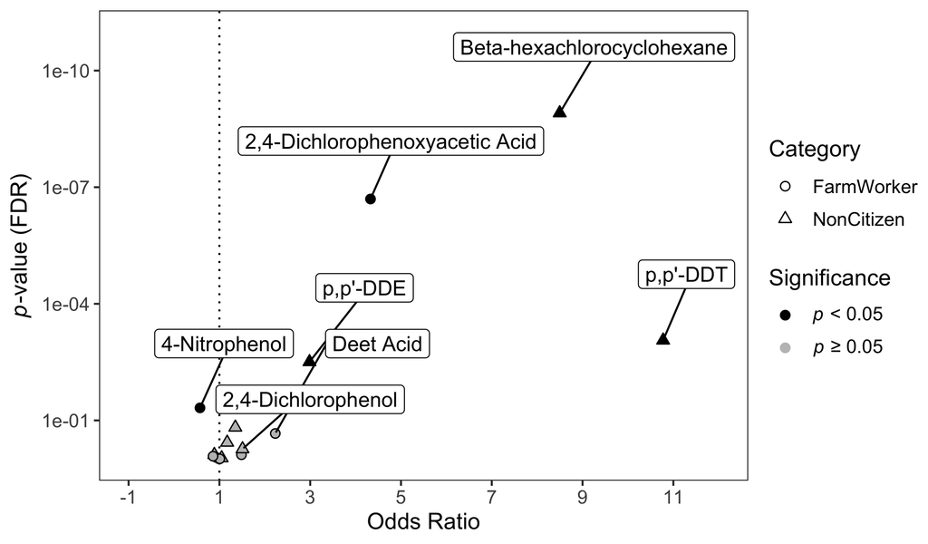

```r
logreg_results_adj %>%
  mutate(p.fdr = p.adjust(p, method="fdr"),
         p.fdr.sig = ifelse(p.fdr<0.05,"*","")) %>%
  filter(!is.na(OR)) %>%
  filter(str_detect(weight, "_[ABC]_", negate=T)) %>%
  left_join(mw %>% select(chem=chemical, commonname)) %>%
  mutate(label=
           case_when(p.fdr < 0.05 ~ commonname,
                     OR> 1.5 ~ commonname,
                     TRUE ~ NA_character_),
         variable = as.factor(variable),
         color = as.factor(ifelse(p.fdr < 0.05, "p < 0.05", "p \u2265 0.05"))) -> vol_plot_data

#Reverse log scale for y axis
reverselog_trans <- function(base = exp(1)) {
  trans <- function(x) -log(x, base)
  inv <- function(x) base^(-x)
  trans_new(paste0("reverselog-", format(base)), trans, inv,
            log_breaks(base = base),
            domain = c(1e-100, Inf))
}

#Breaks for FDR legend
my_breaks = c(1e-8, 1e-5, 5e-2, 1)

#Italicized y axis title
my_y_title <- expression(paste(italic("p"), "-value (FDR)"))

vol_plot_data %>%
  ggplot(aes(x=OR, y=p.fdr, shape=variable, fill=color, label=label), size=1) +
  geom_vline(xintercept = 1, linetype="dotted") +
  #geom_hline(yintercept = 0.05, linetype="dotted") +
  geom_point(size=2) +
  theme_bw() +
  theme(panel.grid.major = element_blank(),
        panel.grid.minor = element_blank(),
        #legend.position="bottom", legend.box="vertical", #legend.margin=margin(),
        #legend.position=c(2,0.005), legend.box="horizontal",
        legend.title = element_text(size=12),
        axis.title = element_text(size=12),
        axis.text = element_text(size=10),
        text = element_text(size = 10),
        legend.margin=margin(t = 0.2, unit='cm'),
        legend.text = element_text(size=10)) +
  scale_shape_manual(values = c(21,24)) +
  scale_fill_manual(name="Significance", values=c('black','gray75'),
                     labels = c(expression(paste(italic("p"), " < 0.05")),
                                expression(paste(italic("p"), " \u2265 0.05"))),
    guide=guide_legend(override.aes =
                         list(color=c('black','gray75'),
                              #shape = c(21,23),
                              order=1))) +
  # scale_color_gradient(name="FDR", trans="log", #values=c('black','gray90'),
  #                      low = "#56B1F7", high = "#132B43",
  #                      breaks = my_breaks, labels = my_breaks) +
  labs(shape="Category") +
  scale_x_continuous(breaks=seq(-1,11,by=2),limits=c(-1, 12)) +
  scale_y_continuous(trans=reverselog_trans(10), limits=c(1, 1e-11),
                     breaks=c(1e-01,1e-04,1e-07,1e-10)) +
  xlab("Odds Ratio") +
  ylab(my_y_title)+
  ggrepel::geom_label_repel(aes(x=OR, y=p.fdr, label = label,
                       #fill=factor(color),
                       #colour="white"
                       ),
                       min.segment.length = 0, seed=42,
                           nudge_x = 1, nudge_y = 1.7,
                           box.padding = 0.5,
                   show.legend = FALSE,
                   direction = "both",
                   inherit.aes = FALSE)
```

```r
#Save figure for publication
#ggsave("vol_plot.pdf", width=6.5, height=3.5, units="in", device=cairo_pdf)
```

### Boxplot Plot (NHANES and Model ACC)

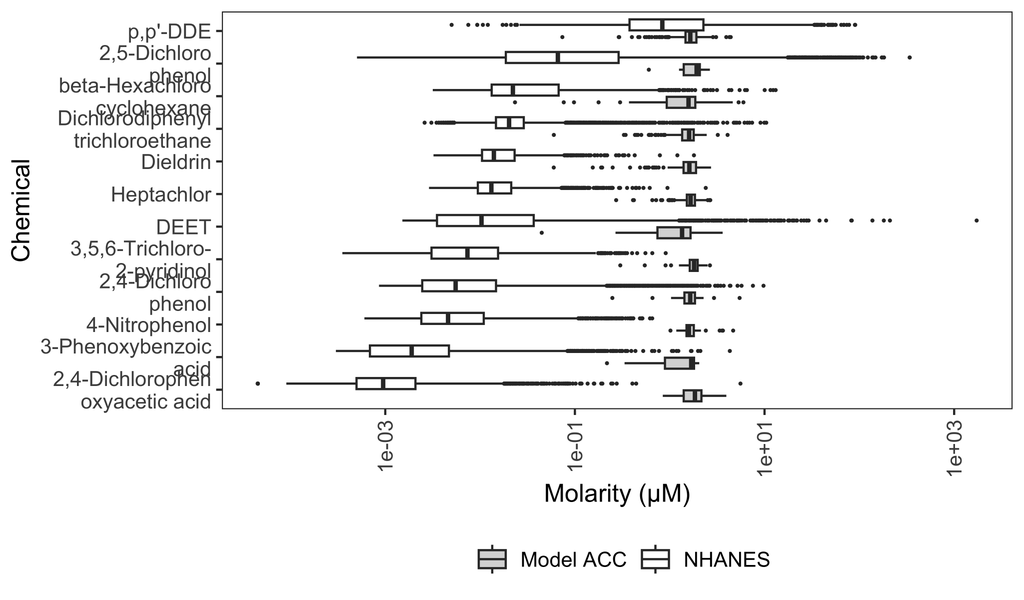

```r
full_chem_demo_dat %>%
  select(casn, molarity) %>%
  #filter(!is.na(molarity)) %>%
  group_by(casn) %>%
  left_join(toxcast %>% select(casn, chnm) %>% unique()) %>%
  ungroup() %>%
  mutate(group="NHANES") -> df_temp

full_chem_demo_dat %>%
  filter(farmwork==1) %>%
  select(casn, molarity) %>%
  #filter(!is.na(molarity)) %>%
  group_by(casn) %>%
  left_join(toxcast %>% select(casn, chnm) %>% unique()) %>%
  ungroup() %>%
  mutate(group="Farmwork") -> df_temp_fw

full_chem_demo_dat %>%
  filter(DMDCITZN==1) %>%
  select(casn, molarity) %>%
  #filter(!is.na(molarity)) %>%
  group_by(casn) %>%
  left_join(toxcast %>% select(casn, chnm) %>% unique()) %>%
  ungroup() %>%
  mutate(group="Noncitizen") -> df_temp_nc

toxcast %>%
  select(casn, molarity=modl_acc, chnm) %>%
  filter(!is.na(molarity)) %>%
  mutate(group="Model ACC") %>%
  rbind(df_temp) %>%
  rbind(df_temp_fw) %>%
  rbind(df_temp_nc) %>%
  mutate(chnm = as.factor(chnm),
         group = as.factor(group)) %>%
  filter(!chnm %in% c("Chlorpyrifos oxon", "Chlorpyrifos")) -> box_plot_data

box_plot_data$group <- factor(box_plot_data$group,
                              levels = c("Model ACC", "Farmwork", "Noncitizen", "NHANES"))

box_plot_data %>%
  select(chnm) %>%
  distinct() %>%
  mutate(chnm_wrap =
           case_when(
             chnm == "3-Phenoxybenzoic acid"           ~ "3-Phenoxybenzoic\nacid",
             chnm == "Dichlorodiphenyltrichloroethane" ~ "Dichlorodiphenyl\ntrichloroethane",
             chnm == "beta-Hexachlorocyclohexane"      ~ "beta-Hexachloro\ncyclohexane",
             chnm == "2,4-Dichlorophenol"              ~ "2,4-Dichloro\nphenol",
             chnm == "2,4-Dichlorophenoxyacetic acid"  ~ "2,4-Dichlorophen\noxyacetic acid",
             chnm == "3,5,6-Trichloro-2-pyridinol"     ~ "3,5,6-Trichloro-\n2-pyridinol",
             chnm == "2,5-Dichlorophenol"              ~ "2,5-Dichloro\nphenol",
             chnm == "p,p'-DDE"              ~ "p,p'-DDE",
             chnm == "Heptachlor"              ~ "Heptachlor",
             chnm == "Dieldrin"              ~ "Dieldrin",
             chnm == "4-Nitrophenol"              ~ "4-Nitrophenol",
             chnm == "DEET"              ~ "DEET",
             TRUE ~ NA_character_
           ))-> chnm_wrap_names

#Order boxplots
box_plot_data %>%
  group_by(chnm, group) %>%
  summarise(med_mol = median(molarity,na.rm=TRUE)) %>%
  ungroup() -> group_medians

box_plot_data %>%
  filter(group %in% c("Model ACC", "NHANES")) %>%
  left_join(group_medians %>% filter(group=="NHANES") %>% select(-group)) %>%
  #filter(group %in% c("Model ACC", "Noncitizen")) %>%
  #left_join(group_medians %>% filter(group=="Noncitizen") %>% select(-group)) %>%
  #filter(group %in% c("Model ACC", "Farmwork")) %>%
  #left_join(group_medians %>% filter(group=="Farmwork") %>% select(-group)) %>%
  left_join(chnm_wrap_names) %>%
  ggplot(aes(x = reorder(chnm_wrap, med_mol),
             y=molarity, fill=group))+
  geom_boxplot(outlier.size=0.25)+
  scale_fill_manual(values=c('gray85','white'))+
  scale_y_continuous(trans="log10")+
  #scale_x_discrete(labels = function(x) str_wrap(x, width = 10)) +
  theme_bw() +
  theme(
    axis.text.x= element_text(angle=90,hjust=0.95,vjust=0.5),
        panel.grid.major = element_blank(),
        panel.grid.minor = element_blank(),
        legend.position = "bottom",
        #axis.text.x = element_text(angle = 45, vjust = 1, hjust=1),
        legend.title = element_blank(),
        axis.title = element_text(size=12),
        axis.text = element_text(size=10),
        text = element_text(size = 10),
        legend.text = element_text(size=10)) +
  ylab("Molarity (\u03bcM)") +
  xlab("Chemical") +
  coord_flip()
```

```r
#ggsave("box_plot.pdf", width=3.5, height=6.5, units="in", device=cairo_pdf)
```

## Non-parametric demographic data analysis

Look at demographics.

```r
bio.demo <- svydesign(id = ~SDMVPSU, strata = ~SDMVSTRA,
                      family = ~quasibinomial, weights = ~WTMEC16YR,
                      nest = TRUE, data = full_chem_demo_dat)

svyranktest(BMXBMI   ~ indiv_chem_bioactiv, bio.demo, test = c("wilcoxon"))
```

```
##
##  Design-based KruskalWallis test
##
## data:  BMXBMI ~ indiv_chem_bioactiv
## t = 7.2642, df = 122, p-value = 3.872e-11
## alternative hypothesis: true difference in mean rank score is not equal to 0
## sample estimates:
## difference in mean rank score
##                    0.02561498
```

```r
svyranktest(RIDAGEYR ~ indiv_chem_bioactiv, bio.demo, test = c("wilcoxon"))
```

```
##
##  Design-based KruskalWallis test
##
## data:  RIDAGEYR ~ indiv_chem_bioactiv
## t = 14.989, df = 122, p-value < 2.2e-16
## alternative hypothesis: true difference in mean rank score is not equal to 0
## sample estimates:
## difference in mean rank score
##                    0.06130358
```

```r
svyranktest(INDFMPIR ~ indiv_chem_bioactiv, bio.demo, test = c("wilcoxon"))
```

```
##
##  Design-based KruskalWallis test
##
## data:  INDFMPIR ~ indiv_chem_bioactiv
## t = -3.7834, df = 122, p-value = 0.0002411
## alternative hypothesis: true difference in mean rank score is not equal to 0
## sample estimates:
## difference in mean rank score
##                   -0.01528269
```

```r
svychisq( ~ SDDSRVYR + indiv_chem_bioactiv, bio.demo, statistic = c("Chisq"))
```

```
##
##  Pearson's X^2: Rao & Scott adjustment
##
## data:  svychisq(~SDDSRVYR + indiv_chem_bioactiv, bio.demo, statistic = c("Chisq"))
## X-squared = 3039.9, df = 7, p-value < 2.2e-16
```

```r
svychisq( ~ RIAGENDR + indiv_chem_bioactiv, bio.demo, statistic = c("Chisq"))
```

```
##
##  Pearson's X^2: Rao & Scott adjustment
##
## data:  svychisq(~RIAGENDR + indiv_chem_bioactiv, bio.demo, statistic = c("Chisq"))
## X-squared = 6.8532, df = 1, p-value = 0.06465
```

```r
svychisq( ~ RIDRETH1 + indiv_chem_bioactiv, bio.demo, statistic = c("Chisq"))
```

```
##
##  Pearson's X^2: Rao & Scott adjustment
##
## data:  svychisq(~RIDRETH1 + indiv_chem_bioactiv, bio.demo, statistic = c("Chisq"))
## X-squared = 180.28, df = 4, p-value = 2.497e-11
```

```r
svychisq( ~ farmwork + indiv_chem_bioactiv, bio.demo, statistic = c("Chisq"))
```

```
##
##  Pearson's X^2: Rao & Scott adjustment
##
## data:  svychisq(~farmwork + indiv_chem_bioactiv, bio.demo, statistic = c("Chisq"))
## X-squared = 73.314, df = 1, p-value = 4.961e-08
```

```r
#svychisq( ~ citzn    + indiv_chem_bioactiv, bio.demo, statistic = c("Chisq"))
svychisq( ~ DMDBORN  + indiv_chem_bioactiv, bio.demo, statistic = c("Chisq"))
```

```
##
##  Pearson's X^2: Rao & Scott adjustment
##
## data:  svychisq(~DMDBORN + indiv_chem_bioactiv, bio.demo, statistic = c("Chisq"))
## X-squared = 635.04, df = 3, p-value < 2.2e-16
```

```r
svychisq( ~ edu      + indiv_chem_bioactiv, bio.demo, statistic = c("Chisq"))
```

```
##
##  Pearson's X^2: Rao & Scott adjustment
##
## data:  svychisq(~edu + indiv_chem_bioactiv, bio.demo, statistic = c("Chisq"))
## X-squared = 41.412, df = 4, p-value = 0.001125
```

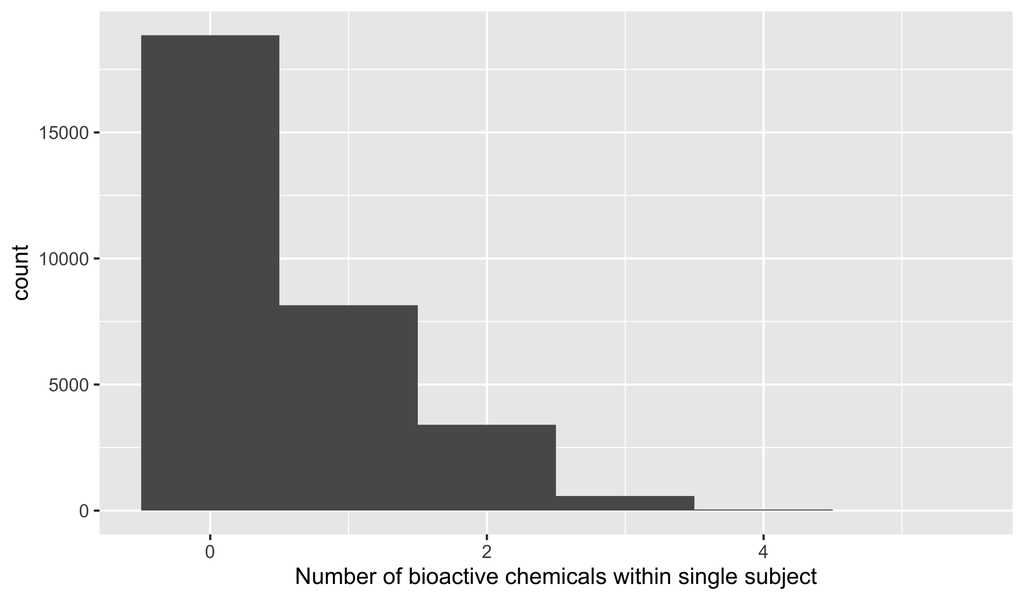

```r
full_chem_demo_dat %>%
  dplyr::select(SEQN,bioactiv_count) %>%
  arrange(SEQN,bioactiv_count) %>%
  distinct() %>%
  ggplot(aes(x=bioactiv_count)) +
  geom_histogram(binwidth=1) + xlab("Number of bioactive chemicals within single subject")
```